# MINI PROJECT-1: MODERN LOW FOOTPRINT CYBER ATTACK DETECTION

```python
d_train['is_ftp_login'].value_counts()
```

```
0    78606
1     2545
4       16
2        6
Name: is_ftp_login, dtype: int64
```

```python
d_train['ct_ftp_cmd'].value_counts()
```

```
0    78606
1     2545
4       16
2        6
Name: ct_ftp_cmd, dtype: int64
```

```python
# Dropping entries with NaN
d_train = d_train.dropna()
d_train
```

|  | id | dur | proto | service | state | spkts | dpkts | sbytes | dbytes | rate | sttl | dttl | sload | dload | sloss | dloss | sinpkt | dinpkt | sjit | djit | swin | stcpb | dtcpb | dwin | tcprtt | synack | ackdat | smean | dmean | … |
| --- | --- | --- | --- | --- | --- | --- | --- | --- | --- | --- | --- | --- | --- | --- | --- | --- | --- | --- | --- | --- | --- | --- | --- | --- | --- | --- | --- | --- | --- | --- |
| 3 | 4 | 1.681642 | tcp | ftp | FIN | 12 | 12 | 628 | 770 | 13.677108 | 62 | 252 | 2.740179e+03 | 3358.622070 | 1 | 3 | 152.876547 | 90.235726 | 259.080172 | 4991.784669 | 255 | 1107119177 | 1047442890 | 255 | 0.000000 | 0.000000 | 0.000000 | 52 | 64 | … |
| 11 | 12 | 2.093085 | tcp | smtp | FIN | 62 | 28 | 56329 | 2212 | 42.520967 | 62 | 252 | 2.118251e+05 | 8152.559082 | 28 | 8 | 34.312868 | 75.092445 | 3253.278833 | 106.113453 | 255 | 1824722662 | 860716719 | 255 | 0.131140 | 0.052852 | 0.078288 | 909 | 79 | … |
| 15 | 16 | 0.000002 | udp | snmp | INT | 2 | 0 | 138 | 0 | 500000.001300 | 254 | 0 | 2.760000e+08 | 0.000000 | 0 | 0 | 0.002000 | 0.000000 | 0.000000 | 0.000000 | 0 | 0 | 0 | 0 | 0.000000 | 0.000000 | 0.000000 | 69 | 0 | … |
| 17 | 18 | 0.393556 | tcp | http | FIN | 10 | 8 | 860 | 1096 | 43.195886 | 62 | 252 | 1.573347e+04 | 19494.048830 | 2 | 2 | 43.728444 | 47.669145 | 2124.837873 | 71.805867 | 255 | 3882971404 | 3084071099 | 255 | 0.120313 | 0.059201 | 0.061112 | 86 | 137 | … |
| 21 | 22 | 0.338017 | tcp | http | FIN | 10 | 6 | 998 | 268 | 44.376468 | 254 | 252 | 2.127704e+04 | 5301.508789 | 2 | 1 | 35.218111 | 56.579801 | 1928.550710 | 82.022258 | 255 | 2665974075 | 3521361798 | 255 | 0.154433 | 0.055109 | 0.099324 | 100 | 45 | … |
| ... | ... | ... | ... | ... | ... | ... | ... | ... | ... | ... | ... | ... | ... | ... | ... | ... | ... | ... | ... | ... | ... | ... | ... | ... | ... | ... | ... | ... | ... | … |
| 175335 | 175336 | 0.000006 | udp | dns | INT | 2 | 0 | 114 | 0 | 166666.660800 | 254 | 0 | 7.600000e+07 | 0.000000 | 0 | 0 | 0.006000 | 0.000000 | 0.000000 | 0.000000 | 0 | 0 | 0 | 0 | 0.000000 | 0.000000 | 0.000000 | 57 | 0 | … |
| 175336 | 175337 | 0.000009 | udp | dns | INT | 2 | 0 | 114 | 0 | 111111.107200 | 254 | 0 | 5.066666e+07 | 0.000000 | 0 | 0 | 0.009000 | 0.000000 | 0.000000 | 0.000000 | 0 | 0 | 0 | 0 | 0.000000 | 0.000000 | 0.000000 | 57 | 0 | … |
| 175338 | 175339 | 0.000009 | udp | dns | INT | 2 | 0 | 114 | 0 | 111111.107200 | 254 | 0 | 5.066666e+07 | 0.000000 | 0 | 0 | 0.009000 | 0.000000 | 0.000000 | 0.000000 | 0 | 0 | 0 | 0 | 0.000000 | 0.000000 | 0.000000 | 57 | 0 | … |
| 175339 | 175340 | 0.000009 | udp | dns | INT | 2 | 0 | 114 | 0 | 111111.107200 | 254 | 0 | 5.066666e+07 | 0.000000 | 0 | 0 | 0.009000 | 0.000000 | 0.000000 | 0.000000 | 0 | 0 | 0 | 0 | 0.000000 | 0.000000 | 0.000000 | 57 | 0 | … |
| 175340 | 175341 | 0.000009 | udp | dns | INT | 2 | 0 | 114 | 0 | 111111.107200 | 254 | 0 | 5.066666e+07 | 0.000000 | 0 | 0 | 0.009000 | 0.000000 | 0.000000 | 0.000000 | 0 | 0 | 0 | 0 | 0.000000 | 0.000000 | 0.000000 | 57 | 0 | … |

81173 rows × 45 columns

```python
# Dropping entries with NaN
d_test = d_test.dropna()
d_test
```

|  | id | dur | proto | service | state | spkts | dpkts | sbytes | dbytes | rate | sttl | dttl | sload | dload | sloss | dloss | sinpkt | dinpkt | sjit | djit | swin | stcpb | dtcpb | dwin | tcprtt | synack | ackdat | smean | dmean | … |
| --- | --- | --- | --- | --- | --- | --- | --- | --- | --- | --- | --- | --- | --- | --- | --- | --- | --- | --- | --- | --- | --- | --- | --- | --- | --- | --- | --- | --- | --- | --- |
| 35 | 36 | 0.983874 | tcp | http | FIN | 10 | 8 | 816 | 1172 | 17.278635 | 62 | 252 | 5976.375000 | 8342.531250 | 2 | 2 | 109.319333 | 124.932859 | 5929.211713 | 192.590406 | 255 | 794167371 | 1624757001 | 255 | 0.206572 | 0.108393 | 0.098179 | 82 | 147 | … |
| 40 | 41 | 1.535254 | tcp | http | FIN | 10 | 10 | 826 | 1266 | 12.375802 | 62 | 252 | 3876.882812 | 5940.385254 | 2 | 2 | 170.481889 | 159.070562 | 11933.065600 | 244.118016 | 255 | 708428911 | 3141441573 | 255 | 0.180318 | 0.103612 | 0.076706 | 83 | 127 | … |
| 45 | 46 | 1.059359 | tcp | http | FIN | 10 | 8 | 830 | 1134 | 16.047441 | 62 | 252 | 5641.147461 | 7498.874512 | 2 | 2 | 117.706556 | 132.899281 | 6102.668305 | 255.756219 | 255 | 1853677305 | 1202418679 | 255 | 0.274887 | 0.128459 | 0.146428 | 83 | 142 | … |
| 49 | 50 | 0.990548 | tcp | http | FIN | 10 | 10 | 804 | 1414 | 19.181301 | 62 | 252 | 5847.268066 | 10281.177730 | 2 | 2 | 110.060889 | 100.616555 | 7172.956819 | 143.497953 | 255 | 1528762476 | 1066585482 | 255 | 0.181441 | 0.084249 | 0.097192 | 80 | 141 | … |
| 72 | 73 | 1.303518 | tcp | http | FIN | 12 | 8 | 898 | 1120 | 14.575939 | 62 | 252 | 5057.083984 | 6014.492676 | 2 | 2 | 118.501635 | 175.467000 | 6491.561713 | 252.408328 | 255 | 1182907296 | 802589817 | 255 | 0.140062 | 0.074510 | 0.065552 | 75 | 140 | … |
| ... | ... | ... | ... | ... | ... | ... | ... | ... | ... | ... | ... | ... | ... | ... | ... | ... | ... | ... | ... | ... | ... | ... | ... | ... | ... | ... | ... | ... | ... | … |
| 81462 | 81463 | 0.818276 | tcp | http | FIN | 60 | 14 | 68199 | 612 | 89.211954 | 254 | 252 | 655651.625000 | 5562.915039 | 27 | 1 | 13.441272 | 56.755152 | 1376.971154 | 76.224305 | 255 | 3137145926 | 3197614932 | 255 | 0.154745 | 0.080450 | 0.074295 | 1137 | 44 | … |
| 81466 | 81467 | 0.825170 | tcp | http | FIN | 60 | 14 | 68199 | 612 | 88.466621 | 254 | 252 | 650173.937500 | 5516.438965 | 27 | 1 | 13.969984 | 57.166383 | 1389.032442 | 82.519703 | 255 | 3567303131 | 4168480199 | 255 | 0.113208 | 0.081998 | 0.031210 | 1137 | 44 | … |
| 81518 | 81519 | 0.874942 | tcp | http | FIN | 60 | 14 | 68199 | 612 | 83.434101 | 254 | 252 | 613188.062500 | 5202.630371 | 27 | 1 | 14.591627 | 63.407922 | 1526.290325 | 97.276484 | 255 | 1516200001 | 1237225352 | 255 | 0.104980 | 0.050635 | 0.054345 | 1137 | 44 | … |
| 81540 | 81541 | 0.740231 | tcp | http | FIN | 60 | 14 | 68199 | 612 | 98.617867 | 254 | 252 | 724779.187500 | 6149.432129 | 27 | 1 | 12.379305 | 53.710461 | 1300.964841 | 83.333812 | 255 | 860363568 | 341738851 | 255 | 0.082721 | 0.041986 | 0.040735 | 1137 | 44 | … |
| 82194 | 82195 | 1.910248 | tcp | ftp | FIN | 62 | 20 | 68109 | 1026 | 42.402870 | 254 | 252 | 280637.906300 | 4083.239258 | 28 | 4 | 31.315540 | 96.738422 | 3675.096013 | 190.842797 | 255 | 1739940755 | 196470105 | 255 | 0.218210 | 0.046945 | 0.171265 | 1099 | 51 | … |

35179 rows × 45 columns

```python
d_train.shape
```

```
(81173, 45)
```

```python
d_test.shape
```

```
(35179, 45)
```

```python
# Check if the data columns in test and train are similar
for col in d_test.columns:
   print(col)
```

```
id
dur
proto
service
state
spkts
dpkts
sbytes
dbytes
rate
sttl
dttl
sload
dload
sloss
dloss
sinpkt
dinpkt
sjit
djit
swin
stcpb
dtcpb
dwin
tcprtt
synack
ackdat
smean
dmean
trans_depth
response_body_len
ct_srv_src
ct_state_ttl
ct_dst_ltm
ct_src_dport_ltm
ct_dst_sport_ltm
ct_dst_src_ltm
is_ftp_login
ct_ftp_cmd
ct_flw_http_mthd
ct_src_ltm
ct_srv_dst
is_sm_ips_ports
attack_cat
label
```

```python
for col in d_train.columns:
   print(col)
```

```
id
dur
proto
service
state
spkts
dpkts
sbytes
dbytes
rate
sttl
dttl
sload
dload
sloss
dloss
sinpkt
dinpkt
sjit
djit
swin
stcpb
dtcpb
dwin
tcprtt
synack
ackdat
smean
dmean
trans_depth
response_body_len
ct_srv_src
ct_state_ttl
ct_dst_ltm
ct_src_dport_ltm
ct_dst_sport_ltm
ct_dst_src_ltm
is_ftp_login
ct_ftp_cmd
ct_flw_http_mthd
ct_src_ltm
ct_srv_dst
is_sm_ips_ports
attack_cat
label
```

## DATA PREPROCESSING

```python
d_train['is_sm_ips_ports'].value_counts()
```

```
0    81173
Name: is_sm_ips_ports, dtype: int64
```

```python
# More than 50 percent of the rows are empty, thereby removing this column will not affect the output
#similarly in test data also the column has more 57 percent of rows to be empty.


#ID is not realted to output feature
d_train.drop('id', axis=1, inplace=True)
d_test.drop('id', axis=1, inplace=True)

#correlation is nearly equal to 0 (from heat map) - stating it is independant of the output.
d_train.drop('spkts', axis=1, inplace=True)
d_test.drop('spkts', axis=1, inplace=True)

#Same data columns - high correlation
d_train.drop('is_ftp_login', axis=1, inplace=True)
d_test.drop('is_ftp_login', axis=1, inplace=True)

#name of the attack is not related to whether the attack takes place or not
d_train.drop('attack_cat', axis=1, inplace=True)
d_test.drop('attack_cat', axis=1, inplace=True)

d_train.drop('is_sm_ips_ports', axis=1, inplace=True)
d_test.drop('is_sm_ips_ports', axis=1, inplace=True)
```

```python
d_train.drop('service', axis=1, inplace=True)
d_test.drop('service', axis=1, inplace=True)
```

```python
#one_hot encoding
encode_text_dummy(d_train,"state")
encode_text_dummy(d_test,"state")
encode_text_dummy(d_train,"proto")
encode_text_dummy(d_test,"proto")
```

```python
#normalising training_data using z_score
numerical_var = ['dur',
 'dpkts',
 'sbytes',
 'dbytes',
 'rate',
 'sttl',
 'dttl',
 'sload',
 'dload',
 'sloss',
 'sinpkt',
 'dinpkt',
 'sjit',
 'djit',
 'swin',
 'stcpb',
 'dtcpb',
 'dwin',
 'tcprtt',
 'ackdat',
 'dmean',
 'ct_srv_src',
 'ct_state_ttl',
 'ct_dst_ltm',
 'ct_src_dport_ltm',
 'ct_dst_sport_ltm',
 'ct_dst_src_ltm',
 'ct_ftp_cmd',
 'ct_flw_http_mthd',
 'ct_src_ltm',
 'ct_srv_dst',
            'synack','dloss','smean','response_body_len','trans_depth']

encode_numeric_zscore(d_train, numerical_var)
```

```python
#Normalising testing_data using z_score
test_numerical_var = ['dur',
 'dpkts',
 'sbytes',
 'dbytes',
 'rate',
 'sttl',
 'dttl',
 'sload',
 'dload',
 'sloss',
 'sinpkt',
 'dinpkt',
 'sjit',
 'djit',
 'swin',
 'stcpb',
 'dtcpb',
 'dwin',
 'tcprtt',
 'ackdat',
 'dmean',
 'ct_srv_src',
 'ct_state_ttl',
 'ct_dst_ltm',
 'ct_src_dport_ltm',
 'ct_dst_sport_ltm',
 'ct_dst_src_ltm',
 'ct_flw_http_mthd',
 'ct_src_ltm',
 'ct_srv_dst',
'synack',
'dloss',
'smean',
'response_body_len',
'trans_depth']



encode_numeric_zscore(d_test, test_numerical_var)
```

```python
# Replacing Infinity values with NaN
d_test.replace([np.inf, -np.inf], np.nan)
```

|  | dur | dpkts | sbytes | dbytes | rate | sttl | dttl | sload | dload | sloss | dloss | sinpkt | dinpkt | sjit | djit | swin | stcpb | dtcpb | dwin | tcprtt | synack | ackdat | smean | dmean | trans_depth | response_body_len | ct_srv_src | ct_state_ttl | ct_dst_ltm | … |
| --- | --- | --- | --- | --- | --- | --- | --- | --- | --- | --- | --- | --- | --- | --- | --- | --- | --- | --- | --- | --- | --- | --- | --- | --- | --- | --- | --- | --- | --- | --- |
| 35 | 0.151351 | -0.056241 | -0.047046 | -0.063536 | -0.654846 | -1.100620 | 1.574372 | -0.636437 | -0.198249 | -0.040185 | -0.057364 | 0.277377 | 0.264234 | 0.110463 | -0.104007 | 1.247402 | -0.037970 | 0.610202 | 1.247476 | 2.615925 | 2.600411 | 2.425021 | -0.189703 | 0.156282 | 0.964780 | -0.060791 | -0.781545 | -0.419802 | -0.748606 | … |
| 40 | 0.357149 | -0.041792 | -0.046999 | -0.063024 | -0.654876 | -1.100620 | 1.574372 | -0.636465 | -0.201148 | -0.040185 | -0.057364 | 0.511351 | 0.370800 | 0.328412 | -0.091636 | 1.247402 | -0.103610 | 1.780554 | 1.247476 | 2.214287 | 2.463579 | 1.775220 | -0.184714 | 0.072002 | 0.964780 | -0.060739 | -0.781545 | -0.419802 | -0.748606 | … |
| 45 | 0.179525 | -0.056241 | -0.046981 | -0.063743 | -0.654853 | -1.100620 | 1.574372 | -0.636442 | -0.199267 | -0.040185 | -0.057364 | 0.309462 | 0.289103 | 0.116760 | -0.088841 | 1.247402 | 0.773169 | 0.284304 | 1.247476 | 3.661019 | 3.174699 | 3.885098 | -0.184714 | 0.135212 | 0.964780 | -0.061118 | -0.850202 | -0.419802 | -0.748606 | … |
| 49 | 0.153842 | -0.041792 | -0.047102 | -0.062218 | -0.654834 | -1.100620 | 1.574372 | -0.636439 | -0.195908 | -0.040185 | -0.057364 | 0.280213 | 0.188327 | 0.155613 | -0.115793 | 1.247402 | 0.524421 | 0.179489 | 1.247476 | 2.231467 | 1.909410 | 2.395153 | -0.199681 | 0.130998 | 0.964780 | -0.059466 | -0.781545 | -0.419802 | 0.755444 | … |
| 72 | 0.270656 | -0.056241 | -0.046664 | -0.063819 | -0.654863 | -1.100620 | 1.574372 | -0.636449 | -0.201059 | -0.040185 | -0.057364 | 0.312503 | 0.421984 | 0.130877 | -0.089645 | 1.247402 | 0.259641 | -0.024224 | 1.247476 | 1.598445 | 1.630680 | 1.437686 | -0.224625 | 0.126784 | 0.964780 | -0.061255 | -0.850202 | -0.419802 | -0.748606 | … |
| ... | ... | ... | ... | ... | ... | ... | ... | ... | ... | ... | ... | ... | ... | ... | ... | ... | ... | ... | ... | ... | ... | ... | ... | ... | ... | ... | ... | ... | ... | … |
| 81462 | 0.089543 | -0.012895 | 0.266896 | -0.066585 | -0.654397 | 0.790657 | 1.574372 | -0.627885 | -0.201604 | 0.270157 | -0.072147 | -0.089400 | 0.051407 | -0.054791 | -0.131945 | 1.247402 | 1.755767 | 1.823900 | 1.247476 | 1.823067 | 1.800683 | 1.702260 | 5.073558 | -0.277757 | 0.964780 | -0.063956 | -0.850202 | -0.419802 | -0.748606 | … |
| 81466 | 0.092116 | -0.012895 | 0.266896 | -0.066585 | -0.654402 | 0.790657 | 1.574372 | -0.627957 | -0.201660 | 0.270157 | -0.072147 | -0.087377 | 0.052691 | -0.054353 | -0.130434 | 1.247402 | 2.085087 | 2.573070 | 1.247476 | 1.187628 | 1.844986 | 0.398452 | 5.073558 | -0.277757 | 0.964780 | -0.063956 | -0.850202 | -0.419802 | 3.144231 | … |
| 81518 | 0.110693 | -0.012895 | 0.266896 | -0.066585 | -0.654433 | 0.790657 | 1.574372 | -0.628444 | -0.202039 | 0.270157 | -0.072147 | -0.084999 | 0.072175 | -0.049370 | -0.126891 | 1.247402 | 0.514804 | 0.311163 | 1.247476 | 1.061754 | 0.947378 | 1.098547 | 5.073558 | -0.277757 | 0.964780 | -0.063956 | -0.781545 | -0.419802 | 1.197812 | … |
| 81540 | 0.060413 | -0.012895 | 0.266896 | -0.066585 | -0.654339 | 0.790657 | 1.574372 | -0.626975 | -0.200896 | 0.270157 | -0.072147 | -0.093463 | 0.041903 | -0.057550 | -0.130238 | 1.247402 | 0.012709 | -0.379840 | 1.247476 | 0.721233 | 0.699844 | 0.686691 | 5.073558 | -0.277757 | 0.964780 | -0.063956 | -0.712887 | -0.419802 | 1.374759 | … |
| 82194 | 0.497113 | 0.030450 | 0.266477 | -0.064331 | -0.654689 | 0.790657 | 1.574372 | -0.632822 | -0.203390 | 0.282571 | -0.027797 | -0.021023 | 0.176221 | 0.028635 | -0.104426 | 1.247402 | 0.686095 | -0.491937 | 1.247476 | 2.793965 | 0.841770 | 4.636697 | 4.883981 | -0.248259 | -0.266491 | -0.063956 | -0.850202 | -0.419802 | -0.748606 | … |

35179 rows × 44 columns

```python
# Replacing Infinity values with NaN
d_train.replace([np.inf, -np.inf], np.nan)
```

|  | dur | dpkts | sbytes | dbytes | rate | sttl | dttl | sload | dload | sloss | dloss | sinpkt | dinpkt | sjit | djit | swin | stcpb | dtcpb | dwin | tcprtt | synack | ackdat | smean | dmean | trans_depth | response_body_len | ct_srv_src | ct_state_ttl | ct_dst_ltm | … |
| --- | --- | --- | --- | --- | --- | --- | --- | --- | --- | --- | --- | --- | --- | --- | --- | --- | --- | --- | --- | --- | --- | --- | --- | --- | --- | --- | --- | --- | --- | --- |
| 3 | 0.174677 | -0.044580 | -0.055932 | -0.077782 | -0.624123 | -1.042527 | 1.554587 | -0.610101 | -0.216534 | -0.061567 | -0.055844 | 0.465346 | 0.190108 | -0.125318 | 0.921565 | 1.185734 | 0.159327 | 0.116305 | 1.185734 | -0.548899 | -0.511111 | -0.542046 | -0.358947 | -0.230851 | -0.197312 | -0.057780 | -0.931741 | -0.340489 | -0.811222 | … |
| 11 | 0.266079 | 0.076680 | 0.169685 | -0.069496 | -0.623956 | -1.042527 | 1.554587 | -0.607521 | -0.211838 | 0.228984 | 0.022395 | -0.036952 | 0.131492 | 0.015802 | -0.156252 | 1.185734 | 0.698403 | -0.024568 | 1.185734 | 1.387128 | 0.976391 | 1.689012 | 3.682398 | -0.171035 | -0.197312 | -0.057780 | -0.857352 | -0.340489 | -0.911291 | … |
| 15 | -0.198900 | -0.135525 | -0.057916 | -0.082207 | 2.287049 | 0.822646 | -0.717582 | 2.795841 | -0.219823 | -0.072328 | -0.102787 | -0.182312 | -0.159170 | -0.137528 | -0.179661 | -0.843349 | -0.672360 | -0.673920 | -0.843349 | -0.548899 | -0.511111 | -0.542046 | -0.278781 | -0.486063 | -0.197312 | -0.057780 | -0.931741 | 0.851546 | -0.911291 | … |
| 17 | -0.111472 | -0.074895 | -0.054992 | -0.075909 | -0.623952 | -1.042527 | 1.554587 | -0.609941 | -0.200730 | -0.050806 | -0.071491 | 0.002937 | 0.025344 | -0.037382 | -0.163820 | 1.185734 | 2.244595 | 1.652802 | 1.185734 | 1.227288 | 1.155081 | 1.199529 | -0.198614 | 0.060251 | 0.689287 | -0.056479 | -0.782963 | -0.340489 | -0.911291 | … |
| 21 | -0.123810 | -0.090052 | -0.054433 | -0.080667 | -0.623945 | 0.822646 | 1.554587 | -0.609873 | -0.214631 | -0.050806 | -0.087139 | -0.033117 | 0.059835 | -0.046634 | -0.161566 | 1.185734 | 1.330366 | 1.982709 | 1.185734 | 1.731003 | 1.039913 | 2.288498 | -0.132594 | -0.306617 | 0.689287 | -0.057780 | -0.559796 | -0.340489 | -0.911291 | … |
| ... | ... | ... | ... | ... | ... | ... | ... | ... | ... | ... | ... | ... | ... | ... | ... | ... | ... | ... | ... | ... | ... | ... | ... | ... | ... | ... | ... | ... | ... | … |
| 175335 | -0.198899 | -0.135525 | -0.058014 | -0.082207 | 0.346214 | 0.822646 | -0.717582 | 0.327742 | -0.219823 | -0.072328 | -0.102787 | -0.182295 | -0.159170 | -0.137528 | -0.179661 | -0.843349 | -0.672360 | -0.673920 | -0.843349 | -0.548899 | -0.511111 | -0.542046 | -0.335369 | -0.486063 | -0.197312 | -0.057780 | 2.341380 | 0.851546 | 2.290940 | … |
| 175336 | -0.198899 | -0.135525 | -0.058014 | -0.082207 | 0.022742 | 0.822646 | -0.717582 | 0.015117 | -0.219823 | -0.072328 | -0.102787 | -0.182282 | -0.159170 | -0.137528 | -0.179661 | -0.843349 | -0.672360 | -0.673920 | -0.843349 | -0.548899 | -0.511111 | -0.542046 | -0.335369 | -0.486063 | -0.197312 | -0.057780 | 0.779209 | 0.851546 | 1.390313 | … |
| 175338 | -0.198899 | -0.135525 | -0.058014 | -0.082207 | 0.022742 | 0.822646 | -0.717582 | 0.015117 | -0.219823 | -0.072328 | -0.102787 | -0.182282 | -0.159170 | -0.137528 | -0.179661 | -0.843349 | -0.672360 | -0.673920 | -0.843349 | -0.548899 | -0.511111 | -0.542046 | -0.335369 | -0.486063 | -0.197312 | -0.057780 | -0.113461 | 0.851546 | -0.711152 | … |
| 175339 | -0.198899 | -0.135525 | -0.058014 | -0.082207 | 0.022742 | 0.822646 | -0.717582 | 0.015117 | -0.219823 | -0.072328 | -0.102787 | -0.182282 | -0.159170 | -0.137528 | -0.179661 | -0.843349 | -0.672360 | -0.673920 | -0.843349 | -0.548899 | -0.511111 | -0.542046 | -0.335369 | -0.486063 | -0.197312 | -0.057780 | 1.225543 | 0.851546 | 1.990731 | … |
| 175340 | -0.198899 | -0.135525 | -0.058014 | -0.082207 | 0.022742 | 0.822646 | -0.717582 | 0.015117 | -0.219823 | -0.072328 | -0.102787 | -0.182282 | -0.159170 | -0.137528 | -0.179661 | -0.843349 | -0.672360 | -0.673920 | -0.843349 | -0.548899 | -0.511111 | -0.542046 | -0.335369 | -0.486063 | -0.197312 | -0.057780 | 1.225543 | 0.851546 | 1.990731 | … |

81173 rows × 44 columns

```python
d_train.shape
```

```
(81173, 44)
```

```python
d_test.shape
```

```
(35179, 44)
```

```python
d_train.dtypes
```

```
dur                  float64
dpkts                float64
sbytes               float64
dbytes               float64
rate                 float64
sttl                 float64
dttl                 float64
sload                float64
dload                float64
sloss                float64
dloss                float64
sinpkt               float64
dinpkt               float64
sjit                 float64
djit                 float64
swin                 float64
stcpb                float64
dtcpb                float64
dwin                 float64
tcprtt               float64
synack               float64
ackdat               float64
smean                float64
dmean                float64
trans_depth          float64
response_body_len    float64
ct_srv_src           float64
ct_state_ttl         float64
ct_dst_ltm           float64
ct_src_dport_ltm     float64
ct_dst_sport_ltm     float64
ct_dst_src_ltm       float64
ct_ftp_cmd           float64
ct_flw_http_mthd     float64
ct_src_ltm           float64
ct_srv_dst           float64
label                  int64
state-CON              uint8
state-FIN              uint8
state-INT              uint8
state-REQ              uint8
state-RST              uint8
proto-tcp              uint8
proto-udp              uint8
dtype: object
```

```python
print(d_train.shape)
```

```
(81173, 44)
```

```python
print(d_test.shape)
```

```
(35179, 44)
```

## SPLITTING_DATA

```python
train_x,train_y = to_xy(d_train,'label')
```

```python
test_x,test_y = to_xy(d_test,'label')
```

```python
Y_train = d_train.label
Y_test = d_test.label
```

## LOGISTIC REGRESSION

```python
# import the class
from sklearn.linear_model import LogisticRegression
from sklearn import metrics
import matplotlib.pyplot as plt

# instantiate the model
logreg = LogisticRegression(solver='lbfgs', multi_class='ovr')

# fit the model with data
logreg.fit(train_x, Y_train)
```

```
LogisticRegression(multi_class='ovr')
```

```python
# predict the response for new observations
#pd.set_option('display.max_rows')
pred_lr = logreg.predict(test_x)
pred_lr
```

```
array([1, 1, 1, ..., 1, 1, 1])
```

### ACCURACY

```python
print("Accuracy", metrics.accuracy_score(Y_test, pred_lr))
```

```
Accuracy 0.9168538048267433
```

### CONFUSION MATRIX, CLASSIFICATION REPORT - PRECISION, RECALL AND F1_SCORE

```python
#confusion matrix, precision score, f1 score and recall it

cm_lr = confusion_matrix(Y_test, pred_lr)
print(cm_lr)

pr = metrics.precision_score(Y_test,pred_lr)
print("Precision score : {}".format(pr))

re = metrics.recall_score(Y_test,pred_lr)
print("Recall score: {}".format(re))

f1_score = metrics.f1_score(Y_test,pred_lr)
print("F1 score: {}".format(f1_score))

print(classification_report(Y_test, pred_lr))
```

```
[[ 6826  2799]
 [  126 25428]]
Precision score : 0.9008396216388564
Recall score: 0.9950692650857008
F1 score: 0.9456127628716461
              precision    recall  f1-score   support

           0       0.98      0.71      0.82      9625
           1       0.90      1.00      0.95     25554

    accuracy                           0.92     35179
   macro avg       0.94      0.85      0.88     35179
weighted avg       0.92      0.92      0.91     35179
```

### PLOTTING CONFUSION MATRIX

```
plotting confusion matrix - Logistic Regression
```

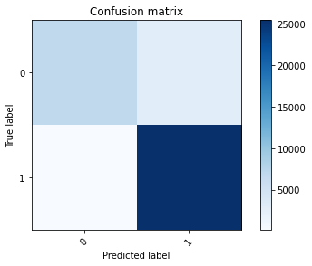

```python
# Plot a confusion matrix.
# cm is the confusion matrix, names are the names of the classes.
label = encode_text_index(d_test,"label")
print("plotting confusion matrix - Logistic Regression")
plt.figure()
plot_confusion_matrix(cm_lr, label)
plt.show()
```

### ROC_CURVE

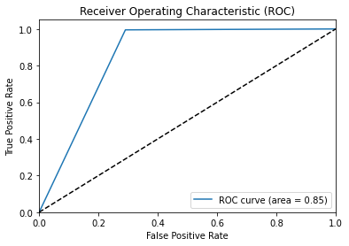

```python
#roc_curve
def plot_roc(pred,y):
    fpr, tpr, thresholds = roc_curve(y, pred)
    roc_auc = auc(fpr, tpr)

    plt.figure()
    plt.plot(fpr, tpr, label='ROC curve (area = %0.2f)' % roc_auc)
    plt.plot([0, 1], [0, 1], 'k--')
    plt.xlim([0.0, 1.0])
    plt.ylim([0.0, 1.05])
    plt.xlabel('False Positive Rate')
    plt.ylabel('True Positive Rate')
    plt.title('Receiver Operating Characteristic (ROC)')
    plt.legend(loc="lower right")
    plt.show()

plot_roc(pred_lr,Y_test)
```

## K-NEAREST NEIGHBOURS

```python
#K-NEAREST NEIGHBOURS!!!
```

```python
from sklearn.neighbors import KNeighborsClassifier
from sklearn import metrics
```

```python
print(d_test.shape)
print(d_train.shape)
print(Y_test.shape)
```

```
(35179, 44)
(81173, 44)
(35179,)
```

```python
knn = KNeighborsClassifier(n_neighbors=20)
```

```python
knn.fit(train_x,Y_train)
```

```
KNeighborsClassifier(n_neighbors=20)
```

```python
knn_pred = knn.predict(test_x)
```

### ACCURACY

```python
accuracy = metrics.accuracy_score(Y_test,knn_pred)
print(accuracy)
```

```
0.9324881321242787
```

### CONFUSION MATRIX, CLASSIFICATION REPORT - PRECISION, RECALL AND F1_SCORE

```python
#confusion matrix, precision score, f1 score and recall it

cm_knn = confusion_matrix(Y_test, knn_pred)
print(cm_knn)

pr = metrics.precision_score(Y_test,knn_pred)
print("Precision score : {}".format(pr))

re = metrics.recall_score(Y_test,knn_pred)
print("Recall score: {}".format(re))

f1_score = metrics.f1_score(Y_test,knn_pred)
print("F1 score: {}".format(f1_score))

print(classification_report(Y_test, knn_pred))
```

```
[[ 7308  2317]
 [   58 25496]]
Precision score : 0.9166936324740229
Recall score: 0.9977302966267512
F1 score: 0.9554968426180973
              precision    recall  f1-score   support

           0       0.99      0.76      0.86      9625
           1       0.92      1.00      0.96     25554

    accuracy                           0.93     35179
   macro avg       0.95      0.88      0.91     35179
weighted avg       0.94      0.93      0.93     35179
```

### PLOTTING CONFUSION MATRIX

```
plotting confusion matrix
```

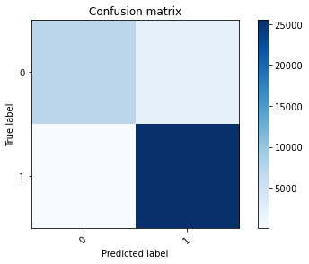

```python
label = encode_text_index(d_test,"label")
print("plotting confusion matrix")
plt.figure()
plot_confusion_matrix(cm_knn, label)
plt.show()
```

### ROC CURVE

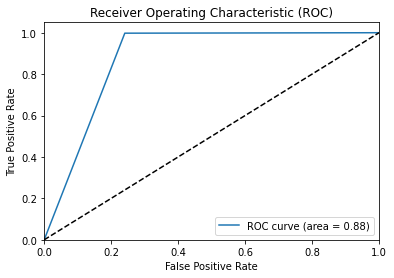

```python
#Roc Curve
plot_roc(knn_pred,Y_test)
```

## Support Vector Machine - SVM

```python
# Support Vector Machine is configured with kernel as linear, max_iteration with 200 and degree as 6
```

```python
from sklearn import svm, datasets
```

```python
#create svm classifier
clf = svm.SVC(kernel = 'linear',max_iter = 200, degree = 6, probability = True)
```

```python
#fit the svm_classifier to data
clf.fit(train_x,Y_train)
```

```
SVC(degree=6, kernel='linear', max_iter=200, probability=True)
```

```python
#predict response
pred_svm = clf.predict(test_x)
```

### ACCURACY

```python
accuracy = metrics.accuracy_score(Y_test,pred_svm)
print('Accuracy=',accuracy)
```

```
Accuracy= 0.727962705022883
```

### CONFUSION MATRIX, CLASSIFICATION REPORT - PRECISION, RECALL AND F1 SCORE

```python
#confusion matrix, precision score, f1 score and recall it
import numpy as np
from sklearn import svm, datasets
from sklearn.model_selection import train_test_split
from sklearn.metrics import confusion_matrix, classification_report
from sklearn.metrics import plot_confusion_matrix

cm_svm = confusion_matrix(Y_test, pred_svm)
print(cm_svm)

pr = metrics.precision_score(Y_test,pred_svm)
print("Precision score : {}".format(pr))

re = metrics.recall_score(Y_test,pred_svm)
print("Recall score: {}".format(re))

f1_score = metrics.f1_score(Y_test,pred_svm)
print("F1 score: {}".format(f1_score))


print(classification_report(Y_test, pred_svm))
```

```
[[  147  9478]
 [   92 25462]]
Precision score : 0.728734974241557
Recall score: 0.996399780856226
F1 score: 0.8418024928092042
              precision    recall  f1-score   support

           0       0.62      0.02      0.03      9625
           1       0.73      1.00      0.84     25554

    accuracy                           0.73     35179
   macro avg       0.67      0.51      0.44     35179
weighted avg       0.70      0.73      0.62     35179
```

### PLOTTING CONFUSION MATRIX

```
plotting confusion matrix
```

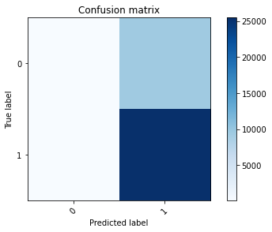

```python
#Confusion matrix
# Plot a confusion matrix.
# cm is the confusion matrix, names are the names of the classes.
def plot_confusion_matrix(cm, names, title='Confusion matrix', cmap=plt.cm.Blues):
    plt.imshow(cm, interpolation='nearest', cmap=cmap)
    plt.title(title)
    plt.colorbar()
    tick_marks = np.arange(len(names))
    plt.xticks(tick_marks, names, rotation=45)
    plt.yticks(tick_marks, names)
    plt.tight_layout()
    plt.ylabel('True label')
    plt.xlabel('Predicted label')


label = encode_text_index(d_test,"label")
print("plotting confusion matrix")

plt.figure()
plot_confusion_matrix(cm_svm, label)
plt.show()
```

### ROC CURVE

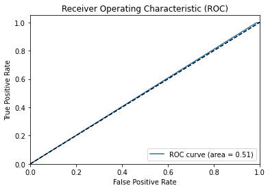

```python
#Roc Curve
plot_roc(pred_svm,Y_test)
```

## Fully Connected Neural networks

#### Importing the headers required for neural Networks

```python
# The details and analysis of Neural Networks can be found in the Report
import numpy as np
from sklearn import svm, datasets
from sklearn.model_selection import train_test_split
from sklearn.metrics import confusion_matrix, classification_report
from sklearn.metrics import plot_confusion_matrix
import sklearn.metrics as metrics
from tensorflow.keras.models import Sequential
from tensorflow.keras.layers import Dense, Activation
from tensorflow.keras.callbacks import EarlyStopping
from tensorflow.keras.callbacks import ModelCheckpoint
```

### Model 1 - Sample - 3 layer FCNN

```python
model = Sequential()

model.add(Dense(12, input_dim = train_x.shape[1], activation='relu'))
model.add(Dense(6, activation='relu'))
model.add(Dense(2, activation='softmax'))
model.add(Dense(train_y.shape[1], activation='sigmoid'))

model.summary()
model.compile(loss='categorical_crossentropy', optimizer='adam')

monitor = EarlyStopping(monitor='val_loss', min_delta=1e-3, patience=2, verbose=2, mode='auto')
checkpointer = ModelCheckpoint(filepath="dnn/best_weights_m1.hdf5", verbose=0, save_best_only=True) # save best model

# patience: number of epochs with no improvement after which training will be stopped
# The test set is checked during training to monitor progress for early stopping
# but is never used for gradient descent (model training)
model.fit(train_x, train_y, validation_data=(test_x,test_y), callbacks=[monitor,checkpointer], verbose=2, epochs=1000)
model.load_weights('dnn/best_weights_m1.hdf5') # load weights from best model
```

```
Model: "sequential_1"
_________________________________________________________________
Layer (type)                 Output Shape              Param #
=================================================================
dense_4 (Dense)              (None, 12)                528
_________________________________________________________________
dense_5 (Dense)              (None, 6)                 78
_________________________________________________________________
dense_6 (Dense)              (None, 2)                 14
_________________________________________________________________
dense_7 (Dense)              (None, 2)                 6
=================================================================
Total params: 626
Trainable params: 626
Non-trainable params: 0
_________________________________________________________________
Train on 81173 samples, validate on 35179 samples
81173/81173 - 11s - loss: 0.2893 - val_loss: 0.2831
81173/81173 - 10s - loss: 0.1087 - val_loss: 0.3025
81173/81173 - 10s - loss: 0.0934 - val_loss: 0.1360
81173/81173 - 10s - loss: 0.0662 - val_loss: 0.1275
81173/81173 - 10s - loss: 0.0560 - val_loss: 0.1329
81173/81173 - 10s - loss: 0.0532 - val_loss: 0.1384
Epoch 00006: early stopping
```

```python
pred_nn_1 = model.predict(test_x)
print(pred_nn_1[0:5]) # print first five predictions
```

```
[[0.13159245 0.02422437]
 [0.13358179 0.0236578 ]
 [0.1219621  0.02728128]
 [0.07103398 0.06081268]
 [0.07570332 0.05553991]]
```

```python
score = np.sqrt(metrics.mean_squared_error(pred_nn_1,test_y))
print("Score (RMSE): {}".format(score))
```

```
Score (RMSE): 0.36064353585243225
```

```python
#confusion matrix, precision score, f1 score and recall it
# The output from the model predict is loaded to the variable pred_nn/pred neural network
pred_nn=pred_nn_1
# Both Pred_nn and test_y are in multiple rows and they have to be merged into one row with whichever column has a higher value
# If Row 1 had data 0.6 and 0.39 => the below func will set the bit which has highest value
pred_nn= np.argmax(pred_nn, axis=1)
test_y_up = np.argmax(test_y, axis=1)
# This value will be assigned to the confusion matrix, precision score, recall score and F1 score
# as they take only a single row to give the values
cm_nn = confusion_matrix(test_y_up, pred_nn)

pr = metrics.precision_score(test_y_up,pred_nn)
print("Precision score : {}".format(pr))

re = metrics.recall_score(test_y_up,pred_nn)
print("Recall score: {}".format(re))

f1_score = metrics.f1_score(test_y_up,pred_nn)
print("F1 score: {}".format(f1_score))

print(classification_report(test_y_up, pred_nn))
```

```
Precision score : 0.9761577072538861
Recall score: 0.9436878766533615
F1 score: 0.9596482152095189
              precision    recall  f1-score   support

           0       0.86      0.94      0.90      9625
           1       0.98      0.94      0.96     25554

    accuracy                           0.94     35179
   macro avg       0.92      0.94      0.93     35179
weighted avg       0.95      0.94      0.94     35179
```

```
Plotting confusion matrix - for Model 1
```

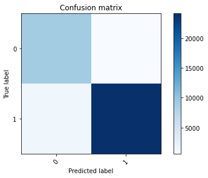

```python
# Plotting confusion matrix is done here.
# The function plot_confusion_matrix() is defined above along with additional function.
# The label from the entire test dataset is taken and compared.
def plot_confusion_matrix(cm, names, title='Confusion matrix', cmap=plt.cm.Blues):
    plt.imshow(cm, interpolation='nearest', cmap=cmap)
    plt.title(title)
    plt.colorbar()
    tick_marks = np.arange(len(names))
    plt.xticks(tick_marks, names, rotation=45)
    plt.yticks(tick_marks, names)
    plt.tight_layout()
    plt.ylabel('True label')
    plt.xlabel('Predicted label')

label = encode_text_index(d_test,"label")
print("Plotting confusion matrix - for Model 1")
plt.figure()
plot_confusion_matrix(cm_nn, label)
plt.show()
```

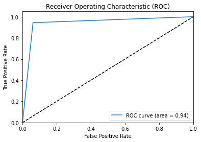

```python
#Roc Curve
plot_roc(pred_nn,test_y_up)
```

```python
model = Sequential()

model.add(Dense(12, input_dim = train_x.shape[1], activation='relu'))
model.add(Dense(64, activation='relu'))
model.add(Dense(32, activation='relu'))
model.add(Dense(16, activation='relu'))
model.add(Dense(2, activation='softmax'))
model.add(Dense(train_y.shape[1], activation='sigmoid'))

model.compile(loss='categorical_crossentropy', optimizer='adam', metrics = ['accuracy'])
model.summary()

monitor = EarlyStopping(monitor='val_loss', min_delta=1e-3, patience=2, verbose=2, mode='auto')
# patience: number of epochs with no improvement after which training will be stopped
# The test set is checked during training to monitor progress for early stopping
# but is never used for gradient descent (model training)
checkpointer = ModelCheckpoint(filepath="dnn/best_weights2.hdf5", verbose=0, save_best_only=True) # save best model
model.fit(train_x, train_y, validation_data=(test_x,test_y), callbacks=[monitor,checkpointer], verbose=2, epochs=100)
model.load_weights('./dnn/best_weights2.hdf5') # load weights from best model
```

```
Model: "sequential_2"
_________________________________________________________________
Layer (type)                 Output Shape              Param #
=================================================================
dense_8 (Dense)              (None, 12)                528
_________________________________________________________________
dense_9 (Dense)              (None, 64)                832
_________________________________________________________________
dense_10 (Dense)             (None, 32)                2080
_________________________________________________________________
dense_11 (Dense)             (None, 16)                528
_________________________________________________________________
dense_12 (Dense)             (None, 2)                 34
_________________________________________________________________
dense_13 (Dense)             (None, 2)                 6
=================================================================
Total params: 4,008
Trainable params: 4,008
Non-trainable params: 0
_________________________________________________________________
Train on 81173 samples, validate on 35179 samples
81173/81173 - 13s - loss: 0.2370 - accuracy: 0.9658 - val_loss: 0.2939 - val_accuracy: 0.9196
81173/81173 - 11s - loss: 0.1093 - accuracy: 0.9783 - val_loss: 0.3052 - val_accuracy: 0.9204
81173/81173 - 11s - loss: 0.1015 - accuracy: 0.9783 - val_loss: 0.3022 - val_accuracy: 0.9204
Epoch 00003: early stopping
```

```python
pred_nn_2 = model.predict(test_x)
print(pred_nn_2[0:5]) # print first five predictions
```

```
[[0.02884659 0.54325026]
 [0.02884659 0.54325026]
 [0.02884659 0.54325026]
 [0.02884659 0.54325026]
 [0.02884659 0.54325026]]
```

```python
score = np.sqrt(metrics.mean_squared_error(pred_nn_2,test_y))
print("Score (RMSE): {}".format(score))
```

```
Score (RMSE): 0.3774062693119049
```

```python
#confusion matrix, precision score, f1 score and recall it
# The output from the model predict is loaded to the variable pred_nn/pred neural network
pred_nn=pred_nn_2
# Both Pred_nn and test_y are in multiple rows and they have to be merged into one row with whichever column has a higher value
# If Row 1 had data 0.6 and 0.39 => the below func will set the bit which has highest value
pred_nn= np.argmax(pred_nn, axis=1)
test_y_up = np.argmax(test_y, axis=1)
# This value will be assigned to the confusion matrix, precision score, recall score and F1 score
# as they take only a single row to give the values
cm_nn = confusion_matrix(test_y_up, pred_nn)

pr = metrics.precision_score(test_y_up,pred_nn)
print("Precision score : {}".format(pr))

re = metrics.recall_score(test_y_up,pred_nn)
print("Recall score: {}".format(re))

f1_score = metrics.f1_score(test_y_up,pred_nn)
print("F1 score: {}".format(f1_score))

print(classification_report(test_y_up, pred_nn))
```

```
Precision score : 0.9011722335993221
Recall score: 0.9987868826798153
F1 score: 0.9474719726780014
              precision    recall  f1-score   support

           0       1.00      0.71      0.83      9625
           1       0.90      1.00      0.95     25554

    accuracy                           0.92     35179
   macro avg       0.95      0.85      0.89     35179
weighted avg       0.93      0.92      0.91     35179
```

```
Plotting confusion matrix - for Model 2
```

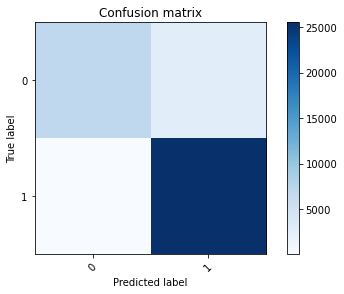

```python
# Plotting confusion matrix is done here.
# The function plot_confusion_matrix() is defined above along with additional function.
# The label from the entire test dataset is taken and compared.
label = encode_text_index(d_test,"label")
print("Plotting confusion matrix - for Model 2")
plt.figure()
plot_confusion_matrix(cm_nn, label)
plt.show()
```

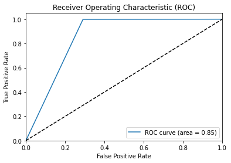

```python
#Roc Curve
plot_roc(pred_nn,test_y_up)
```

## Adam - Optimizer

### Model 3 - SIGMOID

```python
model = Sequential()

#Creating model - fully connected network, no regularization techniques
model = Sequential()
model.add(Dense(50, input_dim = train_x.shape[1], activation='sigmoid'))
model.add(Dense(25, activation='sigmoid'))
model.add(Dense(1, activation='sigmoid'))
model.add(Dense(train_y.shape[1], activation='softmax'))

model.compile(loss='categorical_crossentropy', optimizer='adam', metrics = ['accuracy'])
model.summary()

monitor = EarlyStopping(monitor='val_loss', min_delta=1e-3, patience=2, verbose=2, mode='auto')

# patience: number of epochs with no improvement after which training will be stopped

# The test set is checked during training to monitor progress for early stopping but is never used for gradient descent (model training)
checkpointer = ModelCheckpoint(filepath="dnn/best_weights.hdf5", verbose=0, save_best_only=True) # save best model
model.fit(train_x, train_y, validation_data=(test_x,test_y), callbacks=[monitor,checkpointer], verbose=2, epochs=100)
model.load_weights('./dnn/best_weights.hdf5') # load weights from best model
```

```
Model: "sequential_4"
_________________________________________________________________
Layer (type)                 Output Shape              Param #
=================================================================
dense_14 (Dense)             (None, 50)                2200
_________________________________________________________________
dense_15 (Dense)             (None, 25)                1275
_________________________________________________________________
dense_16 (Dense)             (None, 1)                 26
_________________________________________________________________
dense_17 (Dense)             (None, 2)                 4
=================================================================
Total params: 3,505
Trainable params: 3,505
Non-trainable params: 0
_________________________________________________________________
Train on 81173 samples, validate on 35179 samples
81173/81173 - 10s - loss: 0.2665 - accuracy: 0.9125 - val_loss: 0.3095 - val_accuracy: 0.9202
81173/81173 - 8s - loss: 0.1289 - accuracy: 0.9785 - val_loss: 0.3010 - val_accuracy: 0.9204
81173/81173 - 8s - loss: 0.1085 - accuracy: 0.9785 - val_loss: 0.3040 - val_accuracy: 0.9205
81173/81173 - 8s - loss: 0.1036 - accuracy: 0.9784 - val_loss: 0.3040 - val_accuracy: 0.9205
Epoch 00004: early stopping
```

```python
pred_nn_3 = model.predict(test_x)
print(pred_nn_3[0:5]) # print first five predictions
```

```
[[0.03780645 0.96219355]
 [0.03780685 0.9621932 ]
 [0.03780617 0.96219385]
 [0.03780683 0.9621932 ]
 [0.03780739 0.96219265]]
```

```python
score = np.sqrt(metrics.mean_squared_error(pred_nn_3,test_y))
print("Score (RMSE): {}".format(score))
```

```
Score (RMSE): 0.2746993601322174
```

```python
#confusion matrix, precision score, f1 score and recall it
# The output from the model predict is loaded to the variable pred_nn/pred neural network
pred_nn=pred_nn_3
# Both Pred_nn and test_y are in multiple rows and they have to be merged into one row with whichever column has a higher value
# If Row 1 had data 0.6 and 0.39 => the below func will set the bit which has highest value
pred_nn= np.argmax(pred_nn, axis=1)
test_y_up = np.argmax(test_y, axis=1)
# This value will be assigned to the confusion matrix, precision score, recall score and F1 score
# as they take only a single row to give the values
cm_nn = confusion_matrix(test_y_up, pred_nn)

pr = metrics.precision_score(test_y_up,pred_nn)
print("Precision score : {}".format(pr))

re = metrics.recall_score(test_y_up,pred_nn)
print("Recall score: {}".format(re))

f1_score = metrics.f1_score(test_y_up,pred_nn)
print("F1 score: {}".format(f1_score))

print(classification_report(test_y_up, pred_nn))
```

```
Precision score : 0.9011849344054168
Recall score: 1.0
F1 score: 0.9480244852531997
              precision    recall  f1-score   support

           0       1.00      0.71      0.83      9625
           1       0.90      1.00      0.95     25554

    accuracy                           0.92     35179
   macro avg       0.95      0.85      0.89     35179
weighted avg       0.93      0.92      0.92     35179
```

```
Plotting confusion matrix - for Model 3
```

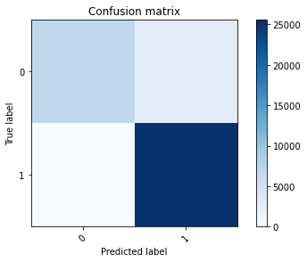

```python
# Plotting confusion matrix is done here.
# The function plot_confusion_matrix() is defined above along with additional function.
# The label from the entire test dataset is taken and compared.

label = encode_text_index(d_test,"label")
print("Plotting confusion matrix - for Model 3")
plt.figure()
plot_confusion_matrix(cm_nn, label)
plt.show()
```

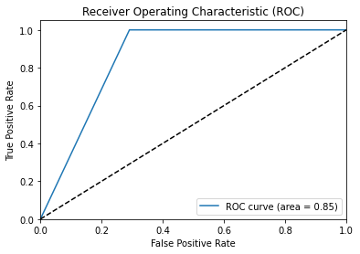

```python
#Roc Curve
plot_roc(pred_nn,test_y_up)
```

### Model 4 - Tanh

```python
model = Sequential()
#Creating model - fully connected network, no regularization techniques
model = Sequential()
model.add(Dense(50, input_dim = train_x.shape[1], activation='tanh'))
model.add(Dense(25, activation='tanh'))
model.add(Dense(1, activation='tanh'))
model.add(Dense(train_y.shape[1], activation='softmax'))

model.compile(loss='categorical_crossentropy', optimizer='adam', metrics = ['accuracy'])
model.summary()

monitor = EarlyStopping(monitor='val_loss', min_delta=1e-3, patience=2, verbose=2, mode='auto')

# patience: number of epochs with no improvement after which training will be stopped

# The test set is checked during training to monitor progress for early stopping but is never used for gradient descent (model training)

checkpointer = ModelCheckpoint(filepath="dnn/best_weights4.hdf5", verbose=0, save_best_only=True) # save best model
model.fit(train_x, train_y, validation_data=(test_x,test_y), callbacks=[monitor,checkpointer], verbose=2, epochs=100)
model.load_weights('./dnn/best_weights4.hdf5') # load weights from best model
```

```
Model: "sequential_6"
_________________________________________________________________
Layer (type)                 Output Shape              Param #
=================================================================
dense_18 (Dense)             (None, 50)                2200
_________________________________________________________________
dense_19 (Dense)             (None, 25)                1275
_________________________________________________________________
dense_20 (Dense)             (None, 1)                 26
_________________________________________________________________
dense_21 (Dense)             (None, 2)                 4
=================================================================
Total params: 3,505
Trainable params: 3,505
Non-trainable params: 0
_________________________________________________________________
Train on 81173 samples, validate on 35179 samples
81173/81173 - 11s - loss: 0.1405 - accuracy: 0.9761 - val_loss: 0.2268 - val_accuracy: 0.9239
81173/81173 - 8s - loss: 0.0724 - accuracy: 0.9789 - val_loss: 0.3187 - val_accuracy: 0.9197
81173/81173 - 8s - loss: 0.0570 - accuracy: 0.9804 - val_loss: 0.3522 - val_accuracy: 0.9194
Epoch 00003: early stopping
```

```python
pred_nn_4 = model.predict(test_x)
print(pred_nn_4[0:5]) # print first five predictions
```

```
[[0.0906211  0.9093789 ]
 [0.07904104 0.920959  ]
 [0.11878586 0.8812142 ]
 [0.052353   0.947647  ]
 [0.07729211 0.9227079 ]]
```

```python
score = np.sqrt(metrics.mean_squared_error(pred_nn_4,test_y))
print("Score (RMSE): {}".format(score))
```

```
Score (RMSE): 0.2507319748401642
```

```python
#confusion matrix, precision score, f1 score and recall it
# The output from the model predict is loaded to the variable pred_nn/pred neural network
pred_nn=pred_nn_4
# Both Pred_nn and test_y are in multiple rows and they have to be merged into one row with whichever column has a higher value
# If Row 1 had data 0.6 and 0.39 => the below func will set the bit which has highest value
pred_nn= np.argmax(pred_nn, axis=1)
test_y_up = np.argmax(test_y, axis=1)
# This value will be assigned to the confusion matrix, precision score, recall score and F1 score
# as they take only a single row to give the values
cm_nn = confusion_matrix(test_y_up, pred_nn)

pr = metrics.precision_score(test_y_up,pred_nn)
print("Precision score : {}".format(pr))

re = metrics.recall_score(test_y_up,pred_nn)
print("Recall score: {}".format(re))

f1_score = metrics.f1_score(test_y_up,pred_nn)
print("F1 score: {}".format(f1_score))

print(classification_report(test_y_up, pred_nn))
```

```
Precision score : 0.9055199064062113
Recall score: 0.9995304061986382
F1 score: 0.9502055393314857
              precision    recall  f1-score   support

           0       1.00      0.72      0.84      9625
           1       0.91      1.00      0.95     25554

    accuracy                           0.92     35179
   macro avg       0.95      0.86      0.89     35179
weighted avg       0.93      0.92      0.92     35179
```

```
Plotting confusion matrix - for Model 4
```

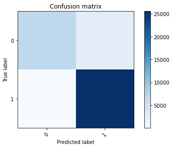

```python
# Plotting confusion matrix is done here.
# The function plot_confusion_matrix() is defined above along with additional function.
# The label from the entire test dataset is taken and compared.

label = encode_text_index(d_test,"label")
print("Plotting confusion matrix - for Model 4")
plt.figure()
plot_confusion_matrix(cm_nn, label)
plt.show()
```

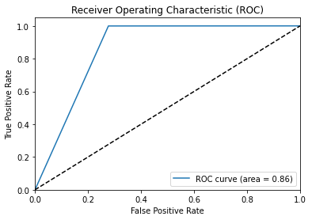

```python
#Roc Curve
plot_roc(pred_nn,test_y_up)
```

### Model 5 - ReLu

```python
#Model 5 with RELU
model = Sequential()

#Creating model - fully connected network, no regularization techniques
model = Sequential()
model.add(Dense(50, input_dim = train_x.shape[1], activation='relu'))
model.add(Dense(25, activation='relu'))
model.add(Dense(1, activation='relu'))
model.add(Dense(train_y.shape[1], activation='softmax'))

model.compile(loss='categorical_crossentropy', optimizer='adam', metrics = ['accuracy'])
model.summary()

monitor = EarlyStopping(monitor='val_loss', min_delta=1e-3, patience=2, verbose=2, mode='auto')

# patience: number of epochs with no improvement after which training will be stopped
# The test set is checked during training to monitor progress for early stopping
# but is never used for gradient descent (model training)
checkpointer = ModelCheckpoint(filepath="dnn/best_weights5.hdf5", verbose=0, save_best_only=True) # save best model
model.fit(train_x, train_y, validation_data=(test_x,test_y), callbacks=[monitor,checkpointer], verbose=2, epochs=100)
model.load_weights('./dnn/best_weights5.hdf5') # load weights from best model
```

```
Model: "sequential_8"
_________________________________________________________________
Layer (type)                 Output Shape              Param #
=================================================================
dense_22 (Dense)             (None, 50)                2200
_________________________________________________________________
dense_23 (Dense)             (None, 25)                1275
_________________________________________________________________
dense_24 (Dense)             (None, 1)                 26
_________________________________________________________________
dense_25 (Dense)             (None, 2)                 4
=================================================================
Total params: 3,505
Trainable params: 3,505
Non-trainable params: 0
_________________________________________________________________
Train on 81173 samples, validate on 35179 samples
81173/81173 - 11s - loss: 0.2063 - accuracy: 0.9759 - val_loss: 0.2690 - val_accuracy: 0.9203
81173/81173 - 8s - loss: 0.1010 - accuracy: 0.9784 - val_loss: 0.3002 - val_accuracy: 0.9203
81173/81173 - 8s - loss: 0.0988 - accuracy: 0.9784 - val_loss: 0.3053 - val_accuracy: 0.9203
Epoch 00003: early stopping
```

```python
pred_nn_5 = model.predict(test_x)
print(pred_nn_5[0:5]) # print first five predictions
```

```
[[0.06025876 0.9397413 ]
 [0.06025876 0.9397413 ]
 [0.06025876 0.9397413 ]
 [0.06025876 0.9397413 ]
 [0.06025876 0.9397413 ]]
```

```python
score = np.sqrt(metrics.mean_squared_error(pred_nn_5,test_y))
print("Score (RMSE): {}".format(score))
```

```
Score (RMSE): 0.27017873525619507
```

```python
#confusion matrix, precision score, f1 score and recall it
# The output from the model predict is loaded to the variable pred_nn/pred neural network
pred_nn=pred_nn_5
# Both Pred_nn and test_y are in multiple rows and they have to be merged into one row with whichever column has a higher value
# If Row 1 had data 0.6 and 0.39 => the below func will set the bit which has highest value
pred_nn= np.argmax(pred_nn, axis=1)
test_y_up = np.argmax(test_y, axis=1)
# This value will be assigned to the confusion matrix, precision score, recall score and F1 score
# as they take only a single row to give the values
cm_nn = confusion_matrix(test_y_up, pred_nn)

pr = metrics.precision_score(test_y_up,pred_nn)
print("Precision score : {}".format(pr))

re = metrics.recall_score(test_y_up,pred_nn)
print("Recall score: {}".format(re))

f1_score = metrics.f1_score(test_y_up,pred_nn)
print("F1 score: {}".format(f1_score))

print(classification_report(test_y_up, pred_nn))
```

```
Precision score : 0.9011531544239517
Recall score: 1.0
F1 score: 0.9480069002615421
              precision    recall  f1-score   support

           0       1.00      0.71      0.83      9625
           1       0.90      1.00      0.95     25554

    accuracy                           0.92     35179
   macro avg       0.95      0.85      0.89     35179
weighted avg       0.93      0.92      0.92     35179
```

```
Plotting confusion matrix - for Model 5
```

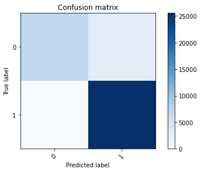

```python
# Plotting confusion matrix is done here.
# The function plot_confusion_matrix() is defined above along with additional function.
# The label from the entire test dataset is taken and compared.

label = encode_text_index(d_test,"label")
print("Plotting confusion matrix - for Model 5")
plt.figure()
plot_confusion_matrix(cm_nn, label)
plt.show()
```

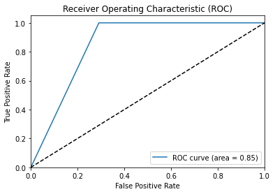

```python
#Roc Curve
plot_roc(pred_nn,test_y_up)
```

## SGD - OPTIMIZER

### Model 6 - Sigmoid

```python
#Model 6 - Optimiser is changed to sgd from adam
model = Sequential()

#Creating model - fully connected network, no regularization techniques
model = Sequential()
model.add(Dense(50, input_dim = train_x.shape[1], activation='sigmoid'))
model.add(Dense(25, activation='sigmoid'))
model.add(Dense(1, activation='sigmoid'))
model.add(Dense(train_y.shape[1], activation='softmax'))

model.compile(loss='categorical_crossentropy', optimizer='sgd', metrics = ['accuracy'])
model.summary()

monitor = EarlyStopping(monitor='val_loss', min_delta=1e-3, patience=2, verbose=2, mode='auto')

# patience: number of epochs with no improvement after which training will be stopped
# The test set is checked during training to monitor progress for early stopping
# but is never used for gradient descent (model training)
checkpointer = ModelCheckpoint(filepath="dnn/best_weights6.hdf5", verbose=0, save_best_only=True) # save best model
model.fit(train_x, train_y, validation_data=(test_x,test_y), callbacks=[monitor,checkpointer], verbose=2, epochs=100)
model.load_weights('./dnn/best_weights6.hdf5') # load weights from best model
```

```
Model: "sequential_10"
_________________________________________________________________
Layer (type)                 Output Shape              Param #
=================================================================
dense_26 (Dense)             (None, 50)                2200
_________________________________________________________________
dense_27 (Dense)             (None, 25)                1275
_________________________________________________________________
dense_28 (Dense)             (None, 1)                 26
_________________________________________________________________
dense_29 (Dense)             (None, 2)                 4
=================================================================
Total params: 3,505
Trainable params: 3,505
Non-trainable params: 0
_________________________________________________________________
Train on 81173 samples, validate on 35179 samples
81173/81173 - 10s - loss: 0.5561 - accuracy: 0.7492 - val_loss: 0.5791 - val_accuracy: 0.7264
81173/81173 - 8s - loss: 0.5153 - accuracy: 0.7599 - val_loss: 0.5050 - val_accuracy: 0.7264
81173/81173 - 8s - loss: 0.3523 - accuracy: 0.8547 - val_loss: 0.3493 - val_accuracy: 0.9200
81173/81173 - 8s - loss: 0.1741 - accuracy: 0.9769 - val_loss: 0.3044 - val_accuracy: 0.9192
81173/81173 - 8s - loss: 0.1283 - accuracy: 0.9771 - val_loss: 0.2980 - val_accuracy: 0.9194
81173/81173 - 8s - loss: 0.1152 - accuracy: 0.9774 - val_loss: 0.2966 - val_accuracy: 0.9197
81173/81173 - 8s - loss: 0.1091 - accuracy: 0.9776 - val_loss: 0.2963 - val_accuracy: 0.9199
81173/81173 - 8s - loss: 0.1052 - accuracy: 0.9777 - val_loss: 0.2914 - val_accuracy: 0.9201
81173/81173 - 8s - loss: 0.1017 - accuracy: 0.9779 - val_loss: 0.2848 - val_accuracy: 0.9203
81173/81173 - 8s - loss: 0.0977 - accuracy: 0.9781 - val_loss: 0.2696 - val_accuracy: 0.9208
81173/81173 - 8s - loss: 0.0928 - accuracy: 0.9783 - val_loss: 0.2617 - val_accuracy: 0.9203
81173/81173 - 9s - loss: 0.0881 - accuracy: 0.9785 - val_loss: 0.2442 - val_accuracy: 0.9203
81173/81173 - 8s - loss: 0.0848 - accuracy: 0.9784 - val_loss: 0.2386 - val_accuracy: 0.9202
81173/81173 - 8s - loss: 0.0827 - accuracy: 0.9782 - val_loss: 0.2388 - val_accuracy: 0.9201
81173/81173 - 7s - loss: 0.0811 - accuracy: 0.9782 - val_loss: 0.2380 - val_accuracy: 0.9201
Epoch 00015: early stopping
```

```python
pred_nn_6 = model.predict(test_x)
print(pred_nn_6[0:5]) # print first five predictions
```

```
[[0.06537051 0.9346295 ]
 [0.09116781 0.9088322 ]
 [0.05391669 0.94608325]
 [0.03677147 0.9632285 ]
 [0.07189483 0.9281052 ]]
```

```python
score = np.sqrt(metrics.mean_squared_error(pred_nn_6,test_y))
print("Score (RMSE): {}".format(score))
```

```
Score (RMSE): 0.2591646909713745
```

```python
#confusion matrix, precision score, f1 score and recall it
# The output from the model predict is loaded to the variable pred_nn/pred neural network
pred_nn=pred_nn_6
# Both Pred_nn and test_y are in multiple rows and they have to be merged into one row with whichever column has a higher value
# If Row 1 had data 0.6 and 0.39 => the below func will set the bit which has highest value
pred_nn= np.argmax(pred_nn, axis=1)
test_y_up = np.argmax(test_y, axis=1)
# This value will be assigned to the confusion matrix, precision score, recall score and F1 score
# as they take only a single row to give the values
cm_nn = confusion_matrix(test_y_up, pred_nn)

pr = metrics.precision_score(test_y_up,pred_nn)
print("Precision score : {}".format(pr))

re = metrics.recall_score(test_y_up,pred_nn)
print("Recall score: {}".format(re))

f1_score = metrics.f1_score(test_y_up,pred_nn)
print("F1 score: {}".format(f1_score))

print(classification_report(test_y_up, pred_nn))
```

```
Precision score : 0.9009803230129064
Recall score: 0.9998434687328794
F1 score: 0.9478409259534056
              precision    recall  f1-score   support

           0       1.00      0.71      0.83      9625
           1       0.90      1.00      0.95     25554

    accuracy                           0.92     35179
   macro avg       0.95      0.85      0.89     35179
weighted avg       0.93      0.92      0.92     35179
```

```
Plotting confusion matrix - for Model 6
```

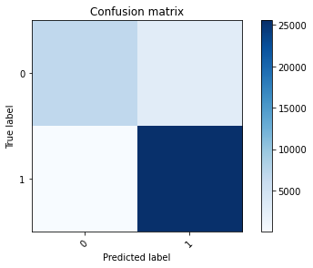

```python
# Plotting confusion matrix is done here.
# The function plot_confusion_matrix() is defined above along with additional function.
# The label from the entire test dataset is taken and compared.

label = encode_text_index(d_test,"label")
print("Plotting confusion matrix - for Model 6")
plt.figure()
plot_confusion_matrix(cm_nn, label)
plt.show()
```

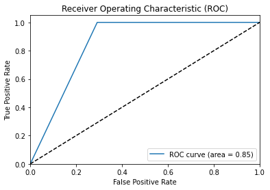

```python
#Roc Curve
plot_roc(pred_nn,test_y_up)
```

### Model 7 - Tanh

```python
#Model 7 - Optimiser is changed to sgd from adam + Tanh
model = Sequential()

#Creating model - fully connected network, no regularization techniques
model = Sequential()
model.add(Dense(50, input_dim = train_x.shape[1], activation='tanh'))
model.add(Dense(25, activation='tanh'))
model.add(Dense(1, activation='tanh'))
model.add(Dense(train_y.shape[1], activation='softmax'))


model.compile(loss='categorical_crossentropy', optimizer='sgd', metrics = ['accuracy'])
model.summary()

monitor = EarlyStopping(monitor='val_loss', min_delta=1e-3, patience=2, verbose=2, mode='auto')

# patience: number of epochs with no improvement after which training will be stopped

# The test set is checked during training to monitor progress for early stopping
# but is never used for gradient descent (model training)
checkpointer = ModelCheckpoint(filepath="dnn/best_weights7.hdf5", verbose=0, save_best_only=True) # save best model
model.fit(train_x, train_y, validation_data=(test_x,test_y), callbacks=[monitor,checkpointer], verbose=2, epochs=100)
model.load_weights('./dnn/best_weights7.hdf5') # load weights from best model
```

```
Model: "sequential_12"
_________________________________________________________________
Layer (type)                 Output Shape              Param #
=================================================================
dense_30 (Dense)             (None, 50)                2200
_________________________________________________________________
dense_31 (Dense)             (None, 25)                1275
_________________________________________________________________
dense_32 (Dense)             (None, 1)                 26
_________________________________________________________________
dense_33 (Dense)             (None, 2)                 4
=================================================================
Total params: 3,505
Trainable params: 3,505
Non-trainable params: 0
_________________________________________________________________
Train on 81173 samples, validate on 35179 samples
81173/81173 - 8s - loss: 0.1641 - accuracy: 0.9741 - val_loss: 0.2181 - val_accuracy: 0.9209
81173/81173 - 7s - loss: 0.0863 - accuracy: 0.9776 - val_loss: 0.2057 - val_accuracy: 0.9200
81173/81173 - 7s - loss: 0.0774 - accuracy: 0.9788 - val_loss: 0.1778 - val_accuracy: 0.9253
81173/81173 - 8s - loss: 0.0728 - accuracy: 0.9795 - val_loss: 0.2201 - val_accuracy: 0.9190
81173/81173 - 7s - loss: 0.0677 - accuracy: 0.9794 - val_loss: 0.2019 - val_accuracy: 0.9192
Epoch 00005: early stopping
```

```python
pred_nn_7 = model.predict(test_x)
print(pred_nn_7[0:5]) # print first five predictions
```

```
[[0.3358199  0.66418004]
 [0.27366623 0.72633374]
 [0.28282923 0.7171708 ]
 [0.07644734 0.92355275]
 [0.15809368 0.84190637]]
```

```python
score = np.sqrt(metrics.mean_squared_error(pred_nn_7,test_y))
print("Score (RMSE): {}".format(score))
```

```
Score (RMSE): 0.2256534993648529
```

```python
#confusion matrix, precision score, f1 score and recall it
# The output from the model predict is loaded to the variable pred_nn/pred neural network
pred_nn=pred_nn_7
# Both Pred_nn and test_y are in multiple rows and they have to be merged into one row with whichever column has a higher value
# If Row 1 had data 0.6 and 0.39 => the below func will set the bit which has highest value
pred_nn= np.argmax(pred_nn, axis=1)
test_y_up = np.argmax(test_y, axis=1)
# This value will be assigned to the confusion matrix, precision score, recall score and F1 score
# as they take only a single row to give the values
cm_nn = confusion_matrix(test_y_up, pred_nn)

pr = metrics.precision_score(test_y_up,pred_nn)
print("Precision score : {}".format(pr))

re = metrics.recall_score(test_y_up,pred_nn)
print("Recall score: {}".format(re))

f1_score = metrics.f1_score(test_y_up,pred_nn)
print("F1 score: {}".format(f1_score))

print(classification_report(test_y_up, pred_nn))
```

```
Precision score : 0.9076490878702749
Recall score: 0.9988260154965954
F1 score: 0.9510572892408011
              precision    recall  f1-score   support

           0       1.00      0.73      0.84      9625
           1       0.91      1.00      0.95     25554

    accuracy                           0.93     35179
   macro avg       0.95      0.86      0.90     35179
weighted avg       0.93      0.93      0.92     35179
```

```
Plotting confusion matrix - for Model 7
```

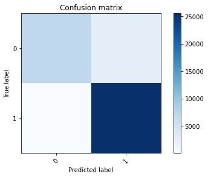

```python
# Plotting confusion matrix is done here.
# The function plot_confusion_matrix() is defined above along with additional function.
# The label from the entire test dataset is taken and compared.

label = encode_text_index(d_test,"label")
print("Plotting confusion matrix - for Model 7")
plt.figure()
plot_confusion_matrix(cm_nn, label)
plt.show()
```

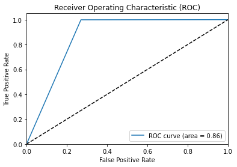

```python
#Roc Curve
plot_roc(pred_nn,test_y_up)
```

### Model 8 - ReLu

```python
#Model 8 - Optimiser is changed to sgd from adam with ReLu
model = Sequential()

#Creating model - fully connected network, no regularization techniques
model = Sequential()
model.add(Dense(50, input_dim = train_x.shape[1], activation='relu'))
model.add(Dense(25, activation='relu'))
model.add(Dense(1, activation='relu'))
model.add(Dense(train_y.shape[1], activation='softmax'))


model.compile(loss='categorical_crossentropy', optimizer='sgd', metrics = ['accuracy'])
model.summary()

monitor = EarlyStopping(monitor='val_loss', min_delta=1e-3, patience=2, verbose=2, mode='auto')

# patience: number of epochs with no improvement after which training will be stopped

# The test set is checked during training to monitor progress for early stopping but is never used for gradient descent (model training)
checkpointer = ModelCheckpoint(filepath="dnn/best_weights8.hdf5", verbose=0, save_best_only=True) # save best model
model.fit(train_x, train_y, validation_data=(test_x,test_y), callbacks=[monitor,checkpointer], verbose=2, epochs=100)
model.load_weights('./dnn/best_weights8.hdf5') # load weights from best model
```

```
Model: "sequential_14"
_________________________________________________________________
Layer (type)                 Output Shape              Param #
=================================================================
dense_34 (Dense)             (None, 50)                2200
_________________________________________________________________
dense_35 (Dense)             (None, 25)                1275
_________________________________________________________________
dense_36 (Dense)             (None, 1)                 26
_________________________________________________________________
dense_37 (Dense)             (None, 2)                 4
=================================================================
Total params: 3,505
Trainable params: 3,505
Non-trainable params: 0
_________________________________________________________________
Train on 81173 samples, validate on 35179 samples
81173/81173 - 10s - loss: 0.5163 - accuracy: 0.7598 - val_loss: 0.5996 - val_accuracy: 0.7264
81173/81173 - 8s - loss: 0.1813 - accuracy: 0.9289 - val_loss: 0.1882 - val_accuracy: 0.9213
81173/81173 - 8s - loss: 0.0782 - accuracy: 0.9779 - val_loss: 0.1662 - val_accuracy: 0.9243
81173/81173 - 8s - loss: 0.0650 - accuracy: 0.9790 - val_loss: 0.1991 - val_accuracy: 0.9204
81173/81173 - 8s - loss: 0.0593 - accuracy: 0.9794 - val_loss: 0.1788 - val_accuracy: 0.9222
Epoch 00005: early stopping
```

```python
pred_nn_8 = model.predict(test_x)
print(pred_nn_8[0:5]) # print first five predictions
```

```
[[0.21372142 0.78627855]
 [0.36094448 0.6390555 ]
 [0.20335118 0.7966489 ]
 [0.03667351 0.9633266 ]
 [0.10072971 0.8992703 ]]
```

```python
score = np.sqrt(metrics.mean_squared_error(pred_nn_8,test_y))
print("Score (RMSE): {}".format(score))
```

```
Score (RMSE): 0.2280154526233673
```

```python
#confusion matrix, precision score, f1 score and recall it
# The output from the model predict is loaded to the variable pred_nn/pred neural network
pred_nn=pred_nn_8
# Both Pred_nn and test_y are in multiple rows and they have to be merged into one row with whichever column has a higher value
# If Row 1 had data 0.6 and 0.39 => the below func will set the bit which has highest value
pred_nn= np.argmax(pred_nn, axis=1)
test_y_up = np.argmax(test_y, axis=1)
# This value will be assigned to the confusion matrix, precision score, recall score and F1 score
# as they take only a single row to give the values
cm_nn = confusion_matrix(test_y_up, pred_nn)

pr = metrics.precision_score(test_y_up,pred_nn)
print("Precision score : {}".format(pr))

re = metrics.recall_score(test_y_up,pred_nn)
print("Recall score: {}".format(re))

f1_score = metrics.f1_score(test_y_up,pred_nn)
print("F1 score: {}".format(f1_score))

print(classification_report(test_y_up, pred_nn))
```

```
Precision score : 0.9063986932746254
Recall score: 0.9989042811301557
F1 score: 0.9504058381115497
              precision    recall  f1-score   support

           0       1.00      0.73      0.84      9625
           1       0.91      1.00      0.95     25554

    accuracy                           0.92     35179
   macro avg       0.95      0.86      0.90     35179
weighted avg       0.93      0.92      0.92     35179
```

```
Plotting confusion matrix - for Model 8
```

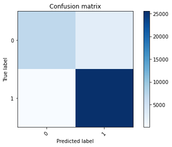

```python
# Plotting confusion matrix is done here.
# The function plot_confusion_matrix() is defined above along with additional function.
# The label from the entire test dataset is taken and compared.

label = encode_text_index(d_test,"label")
print("Plotting confusion matrix - for Model 8")
plt.figure()
plot_confusion_matrix(cm_nn, label)
plt.show()
```

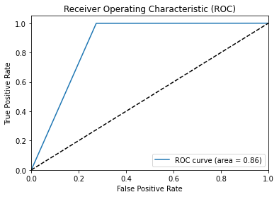

```python
#Roc Curve
plot_roc(pred_nn,test_y_up)
```

### FINAL MODEL WITH CHECKPOINT, ReLu + Softmax

```python
# FINAL MODEL WITH CHECKPOINT
#Creating model - fully connected network, no regularization techniques
model_final = Sequential()

model_final.add(Dense(10, input_dim=train_x.shape[1], activation='relu'))
model_final.add(Dense(5,activation='relu'))
model_final.add(Dense(train_y.shape[1],activation='softmax'))

model_final.compile(loss='categorical_crossentropy', optimizer='adam', metrics = ['accuracy'])

monitor = EarlyStopping(monitor='val_loss', min_delta=1e-3, patience=5, verbose=1, mode='auto')

checkpointer = ModelCheckpoint(filepath="dnn/best_weights.hdf5", verbose=0, save_best_only=True) # save best model

model_final.fit(train_x, train_y, validation_data=(test_x,test_y), callbacks=[monitor,checkpointer], verbose=2, epochs=100)
model_final.load_weights('./dnn/best_weights.hdf5') # load weights from best model
```

```
Train on 81173 samples, validate on 35179 samples
81173/81173 - 12s - loss: 0.0986 - accuracy: 0.9689 - val_loss: 0.1755 - val_accuracy: 0.9214
81173/81173 - 9s - loss: 0.0594 - accuracy: 0.9790 - val_loss: 0.1068 - val_accuracy: 0.9472
81173/81173 - 9s - loss: 0.0546 - accuracy: 0.9798 - val_loss: 0.1532 - val_accuracy: 0.9229
81173/81173 - 9s - loss: 0.0517 - accuracy: 0.9802 - val_loss: 0.1746 - val_accuracy: 0.9226
81173/81173 - 8s - loss: 0.0502 - accuracy: 0.9805 - val_loss: 0.1452 - val_accuracy: 0.9274
81173/81173 - 9s - loss: 0.0488 - accuracy: 0.9809 - val_loss: 0.1608 - val_accuracy: 0.9259
81173/81173 - 8s - loss: 0.0477 - accuracy: 0.9808 - val_loss: 0.1418 - val_accuracy: 0.9319
Epoch 00007: early stopping
```

```python
pred_nn_final = model_final.predict(test_x)
print(pred_nn_final[0:5]) # print first five predictions
```

```
[[0.49242252 0.5075775 ]
 [0.47896093 0.52103907]
 [0.43978617 0.5602138 ]
 [0.09978797 0.90021205]
 [0.29929748 0.7007024 ]]
```

```python
score = np.sqrt(metrics.mean_squared_error(pred_nn_final,test_y))
print("Score (RMSE): {}".format(score))
```

```
Score (RMSE): 0.18613284826278687
```

```python
#confusion matrix, precision score, f1 score and recall it
import numpy as np
from sklearn import svm, datasets
from sklearn.model_selection import train_test_split
from sklearn.metrics import confusion_matrix, classification_report
from sklearn.metrics import plot_confusion_matrix

pred_nn=pred_nn_final
# print(cm_nn)
pred_nn= np.argmax(pred_nn, axis=1)
test_y_up = np.argmax(test_y, axis=1)

cm_nn = confusion_matrix(test_y_up, pred_nn)

pr = metrics.precision_score(test_y_up,pred_nn)
print("Precision score : {}".format(pr))

re = metrics.recall_score(test_y_up,pred_nn)
print("Recall score: {}".format(re))

f1_score = metrics.f1_score(test_y_up,pred_nn)
print("F1 score: {}".format(f1_score))


print(classification_report(test_y_up, pred_nn))
```

```
Precision score : 0.9339902560533353
Recall score: 0.9977694294435313
F1 score: 0.9648269729249049
              precision    recall  f1-score   support

           0       0.99      0.81      0.89      9625
           1       0.93      1.00      0.96     25554

    accuracy                           0.95     35179
   macro avg       0.96      0.91      0.93     35179
weighted avg       0.95      0.95      0.95     35179
```

```
plotting confusion matrix
```

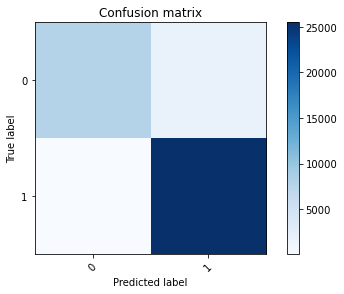

```python
#Confusion matrix
# Plot a confusion matrix.
# cm is the confusion matrix, names are the names of the classes.
def plot_confusion_matrix(cm, names, title='Confusion matrix', cmap=plt.cm.Blues):
    plt.imshow(cm, interpolation='nearest', cmap=cmap)
    plt.title(title)
    plt.colorbar()
    tick_marks = np.arange(len(names))
    plt.xticks(tick_marks, names, rotation=45)
    plt.yticks(tick_marks, names)
    plt.tight_layout()
    plt.ylabel('True label')
    plt.xlabel('Predicted label')


label = encode_text_index(d_test,"label")
print("plotting confusion matrix")

plt.figure()
plot_confusion_matrix(cm_nn, label)
plt.show()
```

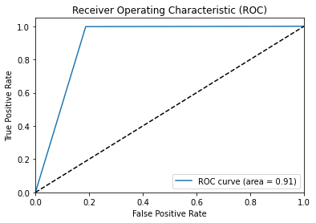

```python
#Roc Curve
plot_roc(pred_nn,test_y_up)
```

## ADDITIONAL FEATURES

### Can you model this intrusion detection problem as a multi-class classification problem so that we can detect the type of each intrusion? How good such predictive model can be in terms of detecting each specific attack?

```python
a_train = pd.read_csv('./data/UNSW_NB15_training-set_csc215.csv',na_values=['NA','?','-'])
a_test = pd.read_csv('./data/UNSW_NB15_test-set_csc215.csv',na_values=['NA','?','-'])
```

```python
df = pd.concat([a_train,a_test])
```

```python
df.describe()
```

|  | id | dur | spkts | dpkts | sbytes | dbytes | rate | sttl | dttl | sload | dload | sloss | dloss | sinpkt | dinpkt | sjit | djit | swin | stcpb | dtcpb | dwin | tcprtt | synack | ackdat | smean | dmean | trans_depth | response_body_len | ct_srv_src | … |
| --- | --- | --- | --- | --- | --- | --- | --- | --- | --- | --- | --- | --- | --- | --- | --- | --- | --- | --- | --- | --- | --- | --- | --- | --- | --- | --- | --- | --- | --- | --- |
| count | 257673.000000 | 257673.000000 | 257673.000000 | 257673.000000 | 2.576730e+05 | 2.576730e+05 | 2.576730e+05 | 257673.000000 | 257673.000000 | 2.576730e+05 | 2.576730e+05 | 257673.000000 | 257673.000000 | 257673.000000 | 257673.000000 | 2.576730e+05 | 257673.000000 | 257673.000000 | 2.576730e+05 | 2.576730e+05 | 257673.000000 | 257673.000000 | 257673.000000 | 257673.000000 | 257673.000000 | 257673.000000 | 257673.000000 | 2.576730e+05 | 257673.000000 | … |
| mean | 72811.823858 | 1.246715 | 19.777144 | 18.514703 | 8.572952e+03 | 1.438729e+04 | 9.125391e+04 | 180.000931 | 84.754957 | 7.060869e+07 | 6.582143e+05 | 4.889317 | 6.743691 | 912.300834 | 98.915462 | 5.419373e+03 | 582.251456 | 121.753661 | 1.006120e+09 | 1.002295e+09 | 119.254629 | 0.046038 | 0.023652 | 0.022386 | 137.639027 | 121.649703 | 0.102242 | 1.968900e+03 | 9.383176 | … |
| std | 48929.917641 | 5.974305 | 135.947152 | 111.985965 | 1.737739e+05 | 1.461993e+05 | 1.603446e+05 | 102.488268 | 112.762131 | 1.857313e+08 | 2.412372e+06 | 65.574953 | 53.702222 | 6922.153239 | 1094.048691 | 4.903450e+04 | 3930.153369 | 127.367443 | 1.367795e+09 | 1.363877e+09 | 127.230477 | 0.092908 | 0.053856 | 0.045771 | 205.901118 | 254.041013 | 0.710593 | 4.962523e+04 | 10.829706 | … |
| min | 1.000000 | 0.000000 | 1.000000 | 0.000000 | 2.400000e+01 | 0.000000e+00 | 0.000000e+00 | 0.000000 | 0.000000 | 0.000000e+00 | 0.000000e+00 | 0.000000 | 0.000000 | 0.000000 | 0.000000 | 0.000000e+00 | 0.000000 | 0.000000 | 0.000000e+00 | 0.000000e+00 | 0.000000 | 0.000000 | 0.000000 | 0.000000 | 24.000000 | 0.000000 | 0.000000 | 0.000000e+00 | 1.000000 | … |
| 25% | 32210.000000 | 0.000008 | 2.000000 | 0.000000 | 1.140000e+02 | 0.000000e+00 | 3.078928e+01 | 62.000000 | 0.000000 | 1.231800e+04 | 0.000000e+00 | 0.000000 | 0.000000 | 0.008000 | 0.000000 | 0.000000e+00 | 0.000000 | 0.000000 | 0.000000e+00 | 0.000000e+00 | 0.000000 | 0.000000 | 0.000000 | 0.000000 | 57.000000 | 0.000000 | 0.000000 | 0.000000e+00 | 2.000000 | … |
| 50% | 64419.000000 | 0.004285 | 4.000000 | 2.000000 | 5.280000e+02 | 1.780000e+02 | 2.955665e+03 | 254.000000 | 29.000000 | 7.439423e+05 | 1.747441e+03 | 0.000000 | 0.000000 | 0.381696 | 0.007000 | 6.736370e-01 | 0.000000 | 0.000000 | 0.000000e+00 | 0.000000e+00 | 0.000000 | 0.000000 | 0.000000 | 0.000000 | 73.000000 | 44.000000 | 0.000000 | 0.000000e+00 | 5.000000 | … |
| 75% | 110923.000000 | 0.685777 | 12.000000 | 10.000000 | 1.362000e+03 | 1.064000e+03 | 1.250000e+05 | 254.000000 | 252.000000 | 8.000000e+07 | 2.210538e+04 | 3.000000 | 2.000000 | 58.094727 | 56.438859 | 2.787367e+03 | 119.712937 | 255.000000 | 2.007375e+09 | 1.992752e+09 | 255.000000 | 0.082082 | 0.036842 | 0.044665 | 100.000000 | 89.000000 | 0.000000 | 0.000000e+00 | 12.000000 | … |
| max | 175341.000000 | 59.999989 | 10646.000000 | 11018.000000 | 1.435577e+07 | 1.465753e+07 | 1.000000e+06 | 255.000000 | 254.000000 | 5.988000e+09 | 2.242273e+07 | 5319.000000 | 5507.000000 | 84371.496000 | 57739.240000 | 1.483831e+06 | 463199.240100 | 255.000000 | 4.294959e+09 | 4.294882e+09 | 255.000000 | 3.821465 | 3.226788 | 2.928778 | 1504.000000 | 1500.000000 | 172.000000 | 6.558056e+06 | 63.000000 | … |

```python
df.columns
```

```
Index(['id', 'dur', 'proto', 'service', 'state', 'spkts', 'dpkts', 'sbytes',
       'dbytes', 'rate', 'sttl', 'dttl', 'sload', 'dload', 'sloss', 'dloss',
       'sinpkt', 'dinpkt', 'sjit', 'djit', 'swin', 'stcpb', 'dtcpb', 'dwin',
       'tcprtt', 'synack', 'ackdat', 'smean', 'dmean', 'trans_depth',
       'response_body_len', 'ct_srv_src', 'ct_state_ttl', 'ct_dst_ltm',
       'ct_src_dport_ltm', 'ct_dst_sport_ltm', 'ct_dst_src_ltm',
       'is_ftp_login', 'ct_ftp_cmd', 'ct_flw_http_mthd', 'ct_src_ltm',
       'ct_srv_dst', 'is_sm_ips_ports', 'attack_cat', 'label'],
      dtype='object')
```

```python
#drop any null values
df[df.isnull().any(axis=1)]
#remove null values
df = df.dropna()
```

```python
#drop any null values
#a_test[a_test.isnull().any(axis=1)]
#remove null values
#a_test = a_test.dropna()
```

```python
df['is_sm_ips_ports'].value_counts
```

```
<bound method IndexOpsMixin.value_counts of 3        0
11       0
15       0
17       0
21       0
        ..
81462    0
81466    0
81518    0
81540    0
82194    0
Name: is_sm_ips_ports, Length: 116352, dtype: int64>
```

```python
# More than 50 percent of the rows are empty, thereby removing this column will not affect the output
#similarly in test data also the column has more 57 percent of rows to be empty.
df.drop('service', axis=1, inplace=True)
#ID is not realted to output feature
df.drop('id', axis=1, inplace=True)
#correlation is nearly equal to 0 - stating it is independant of the output.
df.drop('spkts', axis=1, inplace=True)
#Same data columns - high correlation
df.drop('is_ftp_login', axis=1, inplace=True)
#irrelavant to the output - which is the name of the attack
df.drop('label', axis=1, inplace=True)
#a_test.drop('label', axis=1, inplace=True)
#Many null values
df.drop('is_sm_ips_ports', axis=1, inplace=True)
```

```python
df['attack_cat'].value_counts()
```

```
Generic           57956
Normal            29113
Exploits          21480
DoS                2508
Fuzzers            2266
Reconnaissance     2207
Analysis            564
Worms               148
Backdoor            110
Name: attack_cat, dtype: int64
```

```python
#one_hot encoding
encode_text_dummy(df,"state")
encode_text_dummy(df,"proto")
#label encoding
encode_text_index(df,'attack_cat')
```

```
array(['Analysis', 'Backdoor', 'DoS', 'Exploits', 'Fuzzers', 'Generic',
       'Normal', 'Reconnaissance', 'Worms'], dtype=object)
```

```python
#normalising training_data using z_score
numerical_var = ['dur',
 'dpkts',
 'sbytes',
 'dbytes',
 'rate',
 'sttl',
 'dttl',
 'sload',
 'dload',
 'sloss',
 'sinpkt',
 'dinpkt',
 'sjit',
 'djit',
 'swin',
 'stcpb',
 'dtcpb',
 'dwin',
 'tcprtt',
 'ackdat',
 'dmean',
 'ct_srv_src',
 'ct_state_ttl',
 'ct_dst_ltm',
 'ct_src_dport_ltm',
 'ct_dst_sport_ltm',
 'ct_dst_src_ltm',
 'ct_ftp_cmd',
 'ct_flw_http_mthd',
 'ct_src_ltm',
 'ct_srv_dst',
            'synack','dloss','smean','response_body_len','trans_depth']

encode_numeric_zscore(df, numerical_var)
```

```python
df
```

|  | dur | dpkts | sbytes | dbytes | rate | sttl | dttl | sload | dload | sloss | dloss | sinpkt | dinpkt | sjit | djit | swin | stcpb | dtcpb | dwin | tcprtt | synack | ackdat | smean | dmean | trans_depth | response_body_len | ct_srv_src | ct_state_ttl | ct_dst_ltm | … |
| --- | --- | --- | --- | --- | --- | --- | --- | --- | --- | --- | --- | --- | --- | --- | --- | --- | --- | --- | --- | --- | --- | --- | --- | --- | --- | --- | --- | --- | --- | --- |
| 3 | 0.218308 | -0.039182 | -0.053634 | -0.073974 | -0.632669 | -1.059697 | 1.560517 | -0.617448 | -0.212384 | -0.058996 | -0.051654 | 0.457872 | 0.177226 | -0.113642 | 0.956762 | 1.203932 | 0.171913 | 0.130678 | 1.203953 | -0.547424 | -0.508298 | -0.542948 | -0.353088 | -0.219858 | -0.211688 | -0.058755 | -0.905049 | -0.363132 | -0.759944 | … |
| 11 | 0.320130 | 0.080273 | 0.180798 | -0.065827 | -0.632498 | -1.059697 | 1.560517 | -0.614819 | -0.207426 | 0.243119 | 0.025198 | -0.028034 | 0.122862 | 0.014793 | -0.147150 | 1.203932 | 0.713960 | -0.011114 | 1.203953 | 1.408928 | 0.986624 | 1.727094 | 3.754316 | -0.159090 | -0.211688 | -0.058755 | -0.832542 | -0.363132 | -0.856000 | … |
| 15 | -0.197858 | -0.128774 | -0.055696 | -0.078325 | 2.336441 | 0.812896 | -0.712287 | 2.852579 | -0.215856 | -0.070186 | -0.097766 | -0.168650 | -0.146721 | -0.124755 | -0.171127 | -0.830605 | -0.664358 | -0.664705 | -0.830590 | -0.547424 | -0.508298 | -0.542948 | -0.271611 | -0.479138 | -0.211688 | -0.058755 | -0.905049 | 0.851085 | -0.856000 | … |
| 17 | -0.100463 | -0.069046 | -0.052658 | -0.072133 | -0.632494 | -1.059697 | 1.560517 | -0.617285 | -0.195699 | -0.047807 | -0.067025 | 0.010553 | 0.024412 | -0.033611 | -0.154902 | 1.203932 | 2.268675 | 1.677207 | 1.203953 | 1.247411 | 1.166206 | 1.229058 | -0.190134 | 0.075882 | 0.747474 | -0.057353 | -0.760036 | -0.363132 | -0.856000 | … |
| 21 | -0.114208 | -0.083978 | -0.052077 | -0.076811 | -0.632487 | 0.812896 | 1.560517 | -0.617215 | -0.210375 | -0.047807 | -0.082395 | -0.024324 | 0.056401 | -0.042031 | -0.152594 | 1.203932 | 1.349406 | 2.009266 | 1.203953 | 1.756415 | 1.050464 | 2.337055 | -0.123035 | -0.296832 | 0.747474 | -0.058755 | -0.542516 | -0.363132 | -0.856000 | … |
| ... | ... | ... | ... | ... | ... | ... | ... | ... | ... | ... | ... | ... | ... | ... | ... | ... | ... | ... | ... | ... | ... | ... | ... | ... | ... | ... | ... | ... | ... | … |
| 81462 | 0.004645 | -0.024250 | 0.230756 | -0.074867 | -0.632221 | 0.812896 | 1.560517 | -0.609239 | -0.210104 | 0.231929 | -0.082395 | -0.113572 | 0.057031 | -0.065690 | -0.153904 | 1.203932 | 1.705310 | 1.763427 | 1.203953 | 1.761069 | 1.767235 | 1.611313 | 4.847067 | -0.300883 | 0.747474 | -0.058755 | -0.905049 | -0.363132 | -0.856000 | … |
| 81466 | 0.006351 | -0.024250 | 0.230756 | -0.074867 | -0.632225 | 0.812896 | 1.560517 | -0.609308 | -0.210152 | 0.231929 | -0.082395 | -0.111405 | 0.058507 | -0.065173 | -0.152481 | 1.203932 | 2.030232 | 2.500660 | 1.203953 | 1.141418 | 1.811021 | 0.362019 | 4.847067 | -0.300883 | 0.747474 | -0.058755 | -0.905049 | -0.363132 | 3.370456 | … |
| 81518 | 0.018669 | -0.024250 | 0.230756 | -0.074867 | -0.632255 | 0.812896 | 1.560517 | -0.609773 | -0.210477 | 0.231929 | -0.082395 | -0.108857 | 0.080914 | -0.059285 | -0.149147 | 1.203932 | 0.480915 | 0.274791 | 1.203953 | 1.018672 | 0.923916 | 1.032842 | 4.847067 | -0.300883 | 0.747474 | -0.058755 | -0.832542 | -0.363132 | 1.257228 | … |
| 81540 | -0.014669 | -0.024250 | 0.230756 | -0.074867 | -0.632165 | 0.812896 | 1.560517 | -0.608370 | -0.209498 | 0.231929 | -0.082395 | -0.117924 | 0.046100 | -0.068951 | -0.152297 | 1.203932 | -0.014476 | -0.405203 | 1.203953 | 0.686612 | 0.679279 | 0.638206 | 4.847067 | -0.300883 | 0.747474 | -0.058755 | -0.760036 | -0.363132 | 1.449340 | … |
| 82194 | 0.274882 | 0.020546 | 0.230377 | -0.072528 | -0.632499 | 0.812896 | 1.560517 | -0.613954 | -0.211634 | 0.243119 | -0.036284 | -0.040318 | 0.200571 | 0.032887 | -0.128006 | 1.203932 | 0.649920 | -0.515514 | 1.203953 | 2.707843 | 0.819544 | 4.423059 | 4.664942 | -0.272524 | -0.211688 | -0.058755 | -0.905049 | -0.363132 | -0.856000 | … |

116352 rows × 45 columns

```python
df.shape
```

```
(116352, 45)
```

```python
df['attack_cat'].value_counts()
```

```
5    57956
6    29113
3    21480
2     2508
4     2266
7     2207
0      564
8      148
1      110
Name: attack_cat, dtype: int64
```

```python
x,y = to_xy(df,"attack_cat")
```

```python
p_train, p_test, q_train, q_test = train_test_split(x, y, test_size=0.20, random_state=42)
```

```python
p_train.shape
```

```
(93081, 44)
```

```python
p_test.shape
```

```
(23271, 44)
```

```python
q_train.shape
```

```
(93081, 9)
```

```python
q_test.shape
```

```
(23271, 9)
```

```python
q_test
```

```
array([[0., 0., 0., ..., 0., 0., 0.],
       [0., 0., 0., ..., 0., 0., 0.],
       [0., 0., 0., ..., 0., 0., 0.],
       ...,
       [0., 0., 0., ..., 1., 0., 0.],
       [0., 0., 0., ..., 0., 0., 0.],
       [0., 0., 0., ..., 1., 0., 0.]], dtype=float32)
```

```python
q_test.shape
```

```
(23271, 9)
```

```python
model = Sequential()
model.add(Dense(50, input_dim=p_train.shape[1], activation='relu')) # Hidden 1
model.add(Dense(25, activation='relu')) # Hidden 2
model.add(Dense(q_train.shape[1], activation='softmax')) # Output
model.compile(loss='categorical_crossentropy', optimizer='adam', metrics = ['accuracy'])
model.summary()

monitor = EarlyStopping(monitor='val_loss', min_delta=1e-3, patience=5, verbose=1, mode='auto')
checkpointer = ModelCheckpoint(filepath="dnn/best_weights_additional1.hdf5", verbose=0, save_best_only=True) # save best model

model.fit(p_train, q_train, validation_data=(p_test,q_test), callbacks=[monitor,checkpointer], verbose=2, epochs=100)
model.load_weights('./dnn/best_weights_additional1.hdf5') # load weights from best model
```

```
Model: "sequential_17"
_________________________________________________________________
Layer (type)                 Output Shape              Param #
=================================================================
dense_44 (Dense)             (None, 50)                2250
_________________________________________________________________
dense_45 (Dense)             (None, 25)                1275
_________________________________________________________________
dense_46 (Dense)             (None, 9)                 234
=================================================================
Total params: 3,759
Trainable params: 3,759
Non-trainable params: 0
_________________________________________________________________
Train on 93081 samples, validate on 23271 samples
93081/93081 - 15s - loss: 0.3057 - accuracy: 0.9003 - val_loss: 0.2397 - val_accuracy: 0.9162
93081/93081 - 12s - loss: 0.2334 - accuracy: 0.9180 - val_loss: 0.2208 - val_accuracy: 0.9227
93081/93081 - 10s - loss: 0.2204 - accuracy: 0.9214 - val_loss: 0.2102 - val_accuracy: 0.9255
93081/93081 - 9s - loss: 0.2147 - accuracy: 0.9221 - val_loss: 0.2071 - val_accuracy: 0.9232
93081/93081 - 9s - loss: 0.2093 - accuracy: 0.9241 - val_loss: 0.2018 - val_accuracy: 0.9281
93081/93081 - 9s - loss: 0.2044 - accuracy: 0.9255 - val_loss: 0.1973 - val_accuracy: 0.9292
93081/93081 - 9s - loss: 0.2003 - accuracy: 0.9270 - val_loss: 0.1964 - val_accuracy: 0.9272
93081/93081 - 9s - loss: 0.1971 - accuracy: 0.9284 - val_loss: 0.1911 - val_accuracy: 0.9304
93081/93081 - 9s - loss: 0.1933 - accuracy: 0.9291 - val_loss: 0.1914 - val_accuracy: 0.9295
93081/93081 - 9s - loss: 0.1906 - accuracy: 0.9301 - val_loss: 0.1901 - val_accuracy: 0.9286
93081/93081 - 8s - loss: 0.1881 - accuracy: 0.9302 - val_loss: 0.1837 - val_accuracy: 0.9317
93081/93081 - 123s - loss: 0.1848 - accuracy: 0.9317 - val_loss: 0.1844 - val_accuracy: 0.9315
93081/93081 - 10s - loss: 0.1830 - accuracy: 0.9323 - val_loss: 0.1804 - val_accuracy: 0.9331
93081/93081 - 11s - loss: 0.1814 - accuracy: 0.9324 - val_loss: 0.1819 - val_accuracy: 0.9328
93081/93081 - 10s - loss: 0.1802 - accuracy: 0.9336 - val_loss: 0.1781 - val_accuracy: 0.9341
93081/93081 - 8s - loss: 0.1787 - accuracy: 0.9334 - val_loss: 0.1817 - val_accuracy: 0.9315
93081/93081 - 9s - loss: 0.1777 - accuracy: 0.9332 - val_loss: 0.1761 - val_accuracy: 0.9351
93081/93081 - 9s - loss: 0.1764 - accuracy: 0.9341 - val_loss: 0.1803 - val_accuracy: 0.9311
93081/93081 - 8s - loss: 0.1758 - accuracy: 0.9346 - val_loss: 0.1831 - val_accuracy: 0.9325
93081/93081 - 8s - loss: 0.1753 - accuracy: 0.9342 - val_loss: 0.1861 - val_accuracy: 0.9305
93081/93081 - 8s - loss: 0.1743 - accuracy: 0.9352 - val_loss: 0.1773 - val_accuracy: 0.9315
93081/93081 - 8s - loss: 0.1734 - accuracy: 0.9347 - val_loss: 0.1765 - val_accuracy: 0.9348
Epoch 00022: early stopping
```

```python
pred = model.predict(p_test)
print("Shape: {}".format(pred.shape))
print(pred)
```

```
Shape: (23271, 9)
[[2.3322318e-28 0.0000000e+00 6.2180314e-23 ... 1.4927687e-27
  3.6039265e-31 4.4824430e-37]
 [9.0021658e-04 3.5987305e-05 7.2426476e-02 ... 1.4727606e-02
  3.6821238e-04 1.4182707e-07]
 [1.0511947e-07 1.8011104e-09 5.2785891e-04 ... 2.7993630e-05
  1.3063616e-09 3.4796353e-19]
 ...
 [1.8869138e-01 6.1938859e-05 2.5160233e-02 ... 6.7763001e-01
  8.4603718e-03 1.3728163e-04]
 [1.1003689e-31 0.0000000e+00 1.5975045e-27 ... 1.5766078e-32
  1.8498370e-37 0.0000000e+00]
 [2.8405262e-07 2.1157493e-18 5.3426430e-07 ... 9.9995232e-01
  5.7710018e-19 2.1604819e-21]]
```

```python
# Measure RMSE error.  RMSE is common for regression.
score = np.sqrt(metrics.mean_squared_error(pred,q_test))
print("Final score (RMSE): {}".format(score))
```

```
Final score (RMSE): 0.10058151930570602
```

```python
predict_classes = np.argmax(pred,axis=1)

true_classes = np.argmax(q_test,axis=1)

print("Predictions: {}".format(predict_classes))
print("True: {}".format(true_classes))
```

```
Predictions: [5 3 3 ... 6 5 6]
True: [5 3 3 ... 6 5 6]
```

```python
#confusion matrix, precision score, f1 score and recall it
# pred_nn=pred_nn_final
pred_nn= predict_classes
test_y_up = true_classes

cm_nn = confusion_matrix(test_y_up, pred_nn)

pr = metrics.precision_score(test_y_up,pred_nn,average='micro')
print("Precision score : {}".format(pr))

re = metrics.recall_score(test_y_up,pred_nn,average='micro')
print("Recall score: {}".format(re))

f1_score = metrics.f1_score(test_y_up,pred_nn,average='micro')
print("F1 score: {}".format(f1_score))


print(classification_report(test_y_up, pred_nn))
```

```
Precision score : 0.9350693996820076
Recall score: 0.9350693996820076
F1 score: 0.9350693996820076
              precision    recall  f1-score   support

           0       0.65      0.12      0.21       106
           1       0.00      0.00      0.00        17
           2       0.55      0.15      0.23       490
           3       0.85      0.92      0.88      4313
           4       0.64      0.69      0.66       435
           5       1.00      0.99      0.99     11662
           6       0.94      0.97      0.96      5795
           7       0.57      0.68      0.62       430
           8       0.36      0.17      0.24        23

    accuracy                           0.94     23271
   macro avg       0.62      0.52      0.53     23271
weighted avg       0.93      0.94      0.93     23271
```

```
plotting confusion matrix
```

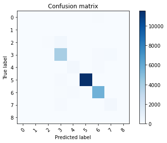

```python
#Confusion matrix
# Plot a confusion matrix.
# cm is the confusion matrix, names are the names of the classes.
def plot_confusion_matrix(cm, names, title='Confusion matrix', cmap=plt.cm.Blues):
    plt.imshow(cm, interpolation='nearest', cmap=cmap)
    plt.title(title)
    plt.colorbar()
    tick_marks = np.arange(len(names))
    plt.xticks(tick_marks, names, rotation=45)
    plt.yticks(tick_marks, names)
    plt.tight_layout()
    plt.ylabel('True label')
    plt.xlabel('Predicted label')


label = encode_text_index(df,'attack_cat')
print("plotting confusion matrix")

plt.figure()
plot_confusion_matrix(cm_nn, label)
plt.show()
```

### Among all the features, can you identify the most important features (this is so called feature importance analysis) and train models only on those important features, e.g., top-10 most important features? What would be the benefits to do that?

### LABEL IS THE OUTPUT COLUMN!

```python
#METHOD - 1
import pandas as pd
import numpy as np
e_train = pd.read_csv('./data/UNSW_NB15_training-set_csc215.csv', na_values=['NA','?','-'])
f_test = pd.read_csv('./data/UNSW_NB15_test-set_csc215.csv',na_values=['NA','?','-'])
```

```python
tf = pd.concat([e_train,f_test])
```

```python
tf.head()
```

|  | id | dur | proto | service | state | spkts | dpkts | sbytes | dbytes | rate | sttl | dttl | sload | dload | sloss | dloss | sinpkt | dinpkt | sjit | djit | swin | stcpb | dtcpb | dwin | tcprtt | synack | ackdat | smean | dmean | … |
| --- | --- | --- | --- | --- | --- | --- | --- | --- | --- | --- | --- | --- | --- | --- | --- | --- | --- | --- | --- | --- | --- | --- | --- | --- | --- | --- | --- | --- | --- | --- |
| 0 | 1 | 0.121478 | tcp | NaN | FIN | 6 | 4 | 258 | 172 | 74.087490 | 252 | 254 | 14158.942380 | 8495.365234 | 0 | 0 | 24.295600 | 8.375000 | 30.177547 | 11.830604 | 255 | 621772692 | 2202533631 | 255 | 0.000000 | 0.000000 | 0.000000 | 43 | 43 | … |
| 1 | 2 | 0.649902 | tcp | NaN | FIN | 14 | 38 | 734 | 42014 | 78.473372 | 62 | 252 | 8395.112305 | 503571.312500 | 2 | 17 | 49.915000 | 15.432865 | 61.426934 | 1387.778330 | 255 | 1417884146 | 3077387971 | 255 | 0.000000 | 0.000000 | 0.000000 | 52 | 1106 | … |
| 2 | 3 | 1.623129 | tcp | NaN | FIN | 8 | 16 | 364 | 13186 | 14.170161 | 62 | 252 | 1572.271851 | 60929.230470 | 1 | 6 | 231.875571 | 102.737203 | 17179.586860 | 11420.926230 | 255 | 2116150707 | 2963114973 | 255 | 0.111897 | 0.061458 | 0.050439 | 46 | 824 | … |
| 3 | 4 | 1.681642 | tcp | ftp | FIN | 12 | 12 | 628 | 770 | 13.677108 | 62 | 252 | 2740.178955 | 3358.622070 | 1 | 3 | 152.876547 | 90.235726 | 259.080172 | 4991.784669 | 255 | 1107119177 | 1047442890 | 255 | 0.000000 | 0.000000 | 0.000000 | 52 | 64 | … |
| 4 | 5 | 0.449454 | tcp | NaN | FIN | 10 | 6 | 534 | 268 | 33.373826 | 254 | 252 | 8561.499023 | 3987.059814 | 2 | 1 | 47.750333 | 75.659602 | 2415.837634 | 115.807000 | 255 | 2436137549 | 1977154190 | 255 | 0.128381 | 0.071147 | 0.057234 | 53 | 45 | … |

```python
tf.drop('service', axis=1, inplace=True)
#one_hot encoding
encode_text_dummy(tf,"state")
#encode_text_dummy(a_test,"state")
encode_text_dummy(tf,"proto")
#encode_text_dummy(a_test,"proto")
#label encoding
encode_text_index(tf,'attack_cat')
#encode_text_index(a_test, 'attack_cat')
```

```
array(['Analysis', 'Backdoor', 'DoS', 'Exploits', 'Fuzzers', 'Generic',
       'Normal', 'Reconnaissance', 'Shellcode', 'Worms'], dtype=object)
```

```python
for col in tf.columns:
    print(col)
```

```
id
dur
spkts
dpkts
sbytes
dbytes
rate
sttl
dttl
sload
dload
sloss
dloss
sinpkt
dinpkt
sjit
djit
swin
stcpb
dtcpb
dwin
tcprtt
synack
ackdat
smean
dmean
trans_depth
response_body_len
ct_srv_src
ct_state_ttl
ct_dst_ltm
ct_src_dport_ltm
ct_dst_sport_ltm
ct_dst_src_ltm
is_ftp_login
ct_ftp_cmd
ct_flw_http_mthd
ct_src_ltm
ct_srv_dst
is_sm_ips_ports
```

[output cut: 131 more lines]

```
proto-ttp
proto-udp
proto-unas
proto-uti
proto-vines
proto-visa
proto-vmtp
proto-vrrp
proto-wb-expak
proto-wb-mon
proto-wsn
proto-xnet
proto-xns-idp
proto-xtp
proto-zero
```

```python
x = tf.iloc[:,tf.columns!='label']  #independent columns
y = tf['label']    #target column i.e label
```

```python
tf.head()
```

|  | id | dur | spkts | dpkts | sbytes | dbytes | rate | sttl | dttl | sload | dload | sloss | dloss | sinpkt | dinpkt | sjit | djit | swin | stcpb | dtcpb | dwin | tcprtt | synack | ackdat | smean | dmean | trans_depth | response_body_len | ct_srv_src | … |
| --- | --- | --- | --- | --- | --- | --- | --- | --- | --- | --- | --- | --- | --- | --- | --- | --- | --- | --- | --- | --- | --- | --- | --- | --- | --- | --- | --- | --- | --- | --- |
| 0 | 1 | 0.121478 | 6 | 4 | 258 | 172 | 74.087490 | 252 | 254 | 14158.942380 | 8495.365234 | 0 | 0 | 24.295600 | 8.375000 | 30.177547 | 11.830604 | 255 | 621772692 | 2202533631 | 255 | 0.000000 | 0.000000 | 0.000000 | 43 | 43 | 0 | 0 | 1 | … |
| 1 | 2 | 0.649902 | 14 | 38 | 734 | 42014 | 78.473372 | 62 | 252 | 8395.112305 | 503571.312500 | 2 | 17 | 49.915000 | 15.432865 | 61.426934 | 1387.778330 | 255 | 1417884146 | 3077387971 | 255 | 0.000000 | 0.000000 | 0.000000 | 52 | 1106 | 0 | 0 | 43 | … |
| 2 | 3 | 1.623129 | 8 | 16 | 364 | 13186 | 14.170161 | 62 | 252 | 1572.271851 | 60929.230470 | 1 | 6 | 231.875571 | 102.737203 | 17179.586860 | 11420.926230 | 255 | 2116150707 | 2963114973 | 255 | 0.111897 | 0.061458 | 0.050439 | 46 | 824 | 0 | 0 | 7 | … |
| 3 | 4 | 1.681642 | 12 | 12 | 628 | 770 | 13.677108 | 62 | 252 | 2740.178955 | 3358.622070 | 1 | 3 | 152.876547 | 90.235726 | 259.080172 | 4991.784669 | 255 | 1107119177 | 1047442890 | 255 | 0.000000 | 0.000000 | 0.000000 | 52 | 64 | 0 | 0 | 1 | … |
| 4 | 5 | 0.449454 | 10 | 6 | 534 | 268 | 33.373826 | 254 | 252 | 8561.499023 | 3987.059814 | 2 | 1 | 47.750333 | 75.659602 | 2415.837634 | 115.807000 | 255 | 2436137549 | 1977154190 | 255 | 0.128381 | 0.071147 | 0.057234 | 53 | 45 | 0 | 0 | 43 | … |

[output not shown]

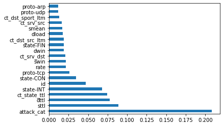

```python
#print the top 20 features that are highly relavant towards the output variable which is 'label '
from sklearn.ensemble import ExtraTreesClassifier
import matplotlib.pyplot as plt
model = ExtraTreesClassifier()
model.fit(x,y)
print(model.feature_importances_) #use inbuilt class feature_importances of tree based classifiers
#plot graph of feature importances for better visualization
feat_importances = pd.Series(model.feature_importances_, index=x.columns)
feat_importances.nlargest(20).plot(kind='barh')
plt.show()
```

[figure not shown]

```python
#METHOD 2:
top_correlated = ['attack_cat','sttl','ct_state_ttl','id','state-INT','state-CON','swin','proto-tcp','ct_dst_src_ltm','rate']
x =  tf[top_correlated]#independent columns
y = tf['label']    #target column i.e label
corrmat = tf.corr()
top_corr_features = corrmat.index
plt.figure(figsize=(20,20))
#plot heat map
g=sns.heatmap(tf[top_corr_features].corr(),annot=True,cmap="RdYlGn")
```

```python
#METHOD 3:
#Chi Square
from sklearn.feature_selection import chi2
pt,qt= to_xy(abs(tf),"label")
```

```python
chi_scores = chi2(pt,qt)
```

```python
chi_scores
p_values = pd.Series(chi_scores[1])
p_values.sort_values(ascending = False , inplace = True)
```

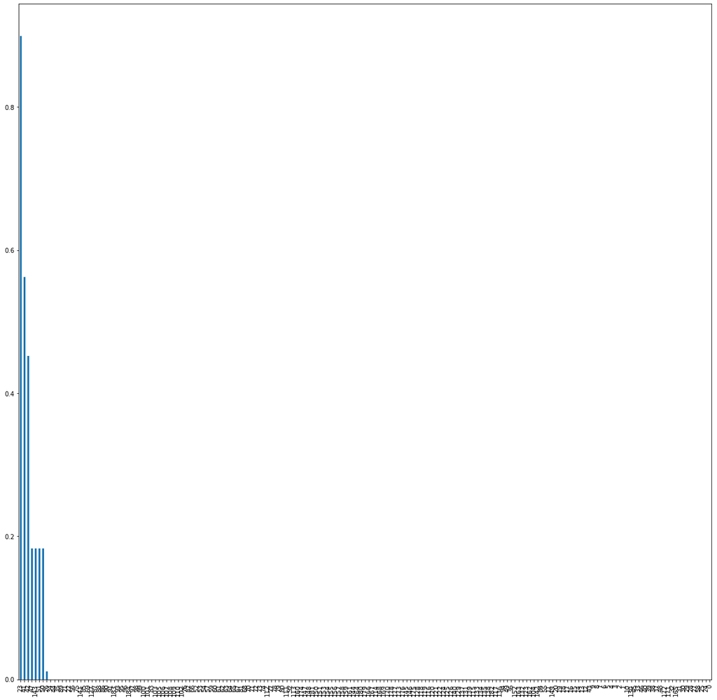

```python
p_values.plot.bar(figsize=(20,20))
```

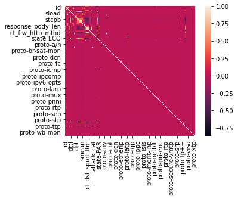

```python
#METHOD 4:
#data correlation - heat maps
import seaborn as sns
sns.heatmap(tf.corr(), vmax=1, square=True)
```